# Christian_Craig_DSC_478_HW2

```python
import os
import pandas as pd
import numpy as np
import matplotlib.pyplot as plt
%matplotlib inline
import os
import zipfile
os.getcwd()
```

```
'C:\\Users\\cjcbg\\Desktop\\DSC 478'
```

Pre Processing for Problem 1

```python
with zipfile.ZipFile('newsgroups.zip','r') as zip_ref:
    zip_ref.extractall()
```

```python
train_labels = pd.read_csv('trainClasses.txt',sep = '\t',header = None)
train_labels
```

|  | 0 | 1 |
| --- | --- | --- |
| 0 | 0 | 0 |
| 1 | 1 | 1 |
| 2 | 2 | 0 |
| 3 | 3 | 1 |
| 4 | 4 | 0 |
| ... | ... | ... |
| 795 | 795 | 0 |
| 796 | 796 | 1 |
| 797 | 797 | 1 |
| 798 | 798 | 1 |
| 799 | 799 | 1 |

800 rows × 2 columns

```python
train_classes = train_labels.iloc[:,1:]
train_classes
```

|  | 1 |
| --- | --- |
| 0 | 0 |
| 1 | 1 |
| 2 | 0 |
| 3 | 1 |
| 4 | 0 |
| ... | ... |
| 795 | 0 |
| 796 | 1 |
| 797 | 1 |
| 798 | 1 |
| 799 | 1 |

800 rows × 1 columns

```python
#sample.housing.map(dict(yes=1, no=0))
train_classesName = train_classes.replace(to_replace=[0, 1], value=['Windows','Hockey'])
train_classesName
```

|  | 1 |
| --- | --- |
| 0 | Windows |
| 1 | Hockey |
| 2 | Windows |
| 3 | Hockey |
| 4 | Windows |
| ... | ... |
| 795 | Windows |
| 796 | Hockey |
| 797 | Hockey |
| 798 | Hockey |
| 799 | Hockey |

800 rows × 1 columns

```python
test_labels = pd.read_csv('testClasses.txt',sep = '\t',header = None)
test_labels
```

|  | 0 | 1 |
| --- | --- | --- |
| 0 | 0 | 1 |
| 1 | 1 | 0 |
| 2 | 2 | 0 |
| 3 | 3 | 1 |
| 4 | 4 | 1 |
| ... | ... | ... |
| 195 | 195 | 1 |
| 196 | 196 | 1 |
| 197 | 197 | 0 |
| 198 | 198 | 1 |
| 199 | 199 | 1 |

200 rows × 2 columns

```python
test_classes = test_labels.iloc[:,1:]
test_classes
```

|  | 1 |
| --- | --- |
| 0 | 1 |
| 1 | 0 |
| 2 | 0 |
| 3 | 1 |
| 4 | 1 |
| ... | ... |
| 195 | 1 |
| 196 | 1 |
| 197 | 0 |
| 198 | 1 |
| 199 | 1 |

200 rows × 1 columns

```python
test_classesName = test_classes.replace(to_replace=[0, 1], value=['Windows','Hockey'])
test_classesName
```

|  | 1 |
| --- | --- |
| 0 | Hockey |
| 1 | Windows |
| 2 | Windows |
| 3 | Hockey |
| 4 | Hockey |
| ... | ... |
| 195 | Hockey |
| 196 | Hockey |
| 197 | Windows |
| 198 | Hockey |
| 199 | Hockey |

200 rows × 1 columns

```python
train_matrix = pd.read_csv('trainMatrixModified.txt',sep = '\t',header = None)
train_matrix.head()
```

|  | 0 | 1 | 2 | 3 | 4 | 5 | 6 | 7 | 8 | 9 | ... | 790 | 791 | 792 | 793 | 794 | 795 | 796 | 797 | 798 | 799 |
| --- | --- | --- | --- | --- | --- | --- | --- | --- | --- | --- | --- | --- | --- | --- | --- | --- | --- | --- | --- | --- | --- |
| 0 | 2.0 | 0.0 | 0.0 | 2.0 | 2.0 | 0.0 | 0.0 | 0.0 | 0.0 | 0.0 | ... | 0.0 | 0.0 | 0.0 | 0.0 | 0.0 | 0.0 | 0.0 | 0.0 | 0.0 | 0.0 |
| 1 | 2.0 | 0.0 | 0.0 | 0.0 | 0.0 | 0.0 | 0.0 | 0.0 | 0.0 | 0.0 | ... | 0.0 | 0.0 | 3.0 | 0.0 | 0.0 | 0.0 | 0.0 | 0.0 | 0.0 | 0.0 |
| 2 | 2.0 | 0.0 | 0.0 | 0.0 | 0.0 | 0.0 | 0.0 | 0.0 | 0.0 | 0.0 | ... | 0.0 | 0.0 | 0.0 | 0.0 | 0.0 | 0.0 | 0.0 | 0.0 | 0.0 | 0.0 |
| 3 | 1.0 | 1.0 | 1.0 | 1.0 | 1.0 | 1.0 | 2.0 | 1.0 | 1.0 | 1.0 | ... | 1.0 | 1.0 | 1.0 | 1.0 | 1.0 | 1.0 | 1.0 | 1.0 | 1.0 | 1.0 |
| 4 | 8.0 | 1.0 | 0.0 | 0.0 | 0.0 | 0.0 | 0.0 | 0.0 | 0.0 | 0.0 | ... | 0.0 | 0.0 | 2.0 | 0.0 | 0.0 | 0.0 | 0.0 | 0.0 | 0.0 | 1.0 |

5 rows × 800 columns

```python
train_matrix
```

|  | 0 | 1 | 2 | 3 | 4 | 5 | 6 | 7 | 8 | 9 | ... | 790 | 791 | 792 | 793 | 794 | 795 | 796 | 797 | 798 | 799 |
| --- | --- | --- | --- | --- | --- | --- | --- | --- | --- | --- | --- | --- | --- | --- | --- | --- | --- | --- | --- | --- | --- |
| 0 | 2.0 | 0.0 | 0.0 | 2.0 | 2.0 | 0.0 | 0.0 | 0.0 | 0.0 | 0.0 | ... | 0.0 | 0.0 | 0.0 | 0.0 | 0.0 | 0.0 | 0.0 | 0.0 | 0.0 | 0.0 |
| 1 | 2.0 | 0.0 | 0.0 | 0.0 | 0.0 | 0.0 | 0.0 | 0.0 | 0.0 | 0.0 | ... | 0.0 | 0.0 | 3.0 | 0.0 | 0.0 | 0.0 | 0.0 | 0.0 | 0.0 | 0.0 |
| 2 | 2.0 | 0.0 | 0.0 | 0.0 | 0.0 | 0.0 | 0.0 | 0.0 | 0.0 | 0.0 | ... | 0.0 | 0.0 | 0.0 | 0.0 | 0.0 | 0.0 | 0.0 | 0.0 | 0.0 | 0.0 |
| 3 | 1.0 | 1.0 | 1.0 | 1.0 | 1.0 | 1.0 | 2.0 | 1.0 | 1.0 | 1.0 | ... | 1.0 | 1.0 | 1.0 | 1.0 | 1.0 | 1.0 | 1.0 | 1.0 | 1.0 | 1.0 |
| 4 | 8.0 | 1.0 | 0.0 | 0.0 | 0.0 | 0.0 | 0.0 | 0.0 | 0.0 | 0.0 | ... | 0.0 | 0.0 | 2.0 | 0.0 | 0.0 | 0.0 | 0.0 | 0.0 | 0.0 | 1.0 |
| ... | ... | ... | ... | ... | ... | ... | ... | ... | ... | ... | ... | ... | ... | ... | ... | ... | ... | ... | ... | ... | ... |
| 5495 | 0.0 | 0.0 | 0.0 | 0.0 | 0.0 | 0.0 | 0.0 | 0.0 | 0.0 | 0.0 | ... | 0.0 | 0.0 | 0.0 | 0.0 | 0.0 | 0.0 | 0.0 | 0.0 | 0.0 | 0.0 |
| 5496 | 0.0 | 0.0 | 0.0 | 0.0 | 0.0 | 0.0 | 0.0 | 0.0 | 0.0 | 0.0 | ... | 0.0 | 0.0 | 0.0 | 0.0 | 0.0 | 0.0 | 0.0 | 0.0 | 0.0 | 0.0 |
| 5497 | 0.0 | 0.0 | 0.0 | 0.0 | 0.0 | 0.0 | 0.0 | 0.0 | 0.0 | 0.0 | ... | 0.0 | 0.0 | 0.0 | 0.0 | 0.0 | 0.0 | 0.0 | 0.0 | 0.0 | 0.0 |
| 5498 | 0.0 | 0.0 | 0.0 | 0.0 | 0.0 | 0.0 | 0.0 | 0.0 | 0.0 | 0.0 | ... | 0.0 | 0.0 | 0.0 | 0.0 | 0.0 | 0.0 | 0.0 | 0.0 | 0.0 | 0.0 |
| 5499 | 0.0 | 0.0 | 0.0 | 0.0 | 0.0 | 0.0 | 0.0 | 0.0 | 0.0 | 0.0 | ... | 0.0 | 0.0 | 0.0 | 0.0 | 0.0 | 0.0 | 0.0 | 0.0 | 0.0 | 0.0 |

5500 rows × 800 columns

```python
transpose_train_matrix = train_matrix.T
transpose_train_matrix
```

|  | 0 | 1 | 2 | 3 | 4 | 5 | 6 | 7 | 8 | 9 | ... | 5490 | 5491 | 5492 | 5493 | 5494 | 5495 | 5496 | 5497 | 5498 | 5499 |
| --- | --- | --- | --- | --- | --- | --- | --- | --- | --- | --- | --- | --- | --- | --- | --- | --- | --- | --- | --- | --- | --- |
| 0 | 2.0 | 2.0 | 2.0 | 1.0 | 8.0 | 6.0 | 2.0 | 8.0 | 2.0 | 4.0 | ... | 0.0 | 0.0 | 0.0 | 0.0 | 0.0 | 0.0 | 0.0 | 0.0 | 0.0 | 0.0 |
| 1 | 0.0 | 0.0 | 0.0 | 1.0 | 1.0 | 0.0 | 0.0 | 0.0 | 0.0 | 0.0 | ... | 0.0 | 0.0 | 0.0 | 0.0 | 0.0 | 0.0 | 0.0 | 0.0 | 0.0 | 0.0 |
| 2 | 0.0 | 0.0 | 0.0 | 1.0 | 0.0 | 0.0 | 0.0 | 2.0 | 0.0 | 1.0 | ... | 0.0 | 0.0 | 0.0 | 0.0 | 0.0 | 0.0 | 0.0 | 0.0 | 0.0 | 0.0 |
| 3 | 2.0 | 0.0 | 0.0 | 1.0 | 0.0 | 0.0 | 0.0 | 0.0 | 0.0 | 0.0 | ... | 0.0 | 0.0 | 0.0 | 0.0 | 0.0 | 0.0 | 0.0 | 0.0 | 0.0 | 0.0 |
| 4 | 2.0 | 0.0 | 0.0 | 1.0 | 0.0 | 0.0 | 0.0 | 0.0 | 0.0 | 0.0 | ... | 0.0 | 0.0 | 0.0 | 0.0 | 0.0 | 0.0 | 0.0 | 0.0 | 0.0 | 0.0 |
| ... | ... | ... | ... | ... | ... | ... | ... | ... | ... | ... | ... | ... | ... | ... | ... | ... | ... | ... | ... | ... | ... |
| 795 | 0.0 | 0.0 | 0.0 | 1.0 | 0.0 | 0.0 | 0.0 | 0.0 | 0.0 | 0.0 | ... | 0.0 | 0.0 | 0.0 | 0.0 | 0.0 | 0.0 | 0.0 | 0.0 | 0.0 | 0.0 |
| 796 | 0.0 | 0.0 | 0.0 | 1.0 | 0.0 | 0.0 | 0.0 | 0.0 | 0.0 | 0.0 | ... | 0.0 | 0.0 | 0.0 | 0.0 | 0.0 | 0.0 | 0.0 | 0.0 | 0.0 | 0.0 |
| 797 | 0.0 | 0.0 | 0.0 | 1.0 | 0.0 | 0.0 | 0.0 | 0.0 | 0.0 | 0.0 | ... | 0.0 | 0.0 | 0.0 | 0.0 | 0.0 | 0.0 | 0.0 | 0.0 | 0.0 | 0.0 |
| 798 | 0.0 | 0.0 | 0.0 | 1.0 | 0.0 | 0.0 | 0.0 | 0.0 | 0.0 | 0.0 | ... | 0.0 | 0.0 | 0.0 | 0.0 | 0.0 | 0.0 | 0.0 | 0.0 | 0.0 | 0.0 |
| 799 | 0.0 | 0.0 | 0.0 | 1.0 | 1.0 | 0.0 | 0.0 | 0.0 | 0.0 | 0.0 | ... | 0.0 | 0.0 | 0.0 | 0.0 | 0.0 | 0.0 | 0.0 | 0.0 | 0.0 | 0.0 |

800 rows × 5500 columns

```python
trainDTM = np.array(transpose_train_matrix)
trainDTM
```

```
array([[2., 2., 2., ..., 0., 0., 0.],
       [0., 0., 0., ..., 0., 0., 0.],
       [0., 0., 0., ..., 0., 0., 0.],
       ...,
       [0., 0., 0., ..., 0., 0., 0.],
       [0., 0., 0., ..., 0., 0., 0.],
       [0., 0., 0., ..., 0., 0., 0.]])
```

```python
#train_matrix = pd.read_csv('trainMatrixModified.txt',sep = '\t',header = None)
test_matrix = pd.read_csv('testMatrixModified.txt',sep = '\t',header = None )
test_matrix
```

|  | 0 | 1 | 2 | 3 | 4 | 5 | 6 | 7 | 8 | 9 | ... | 190 | 191 | 192 | 193 | 194 | 195 | 196 | 197 | 198 | 199 |
| --- | --- | --- | --- | --- | --- | --- | --- | --- | --- | --- | --- | --- | --- | --- | --- | --- | --- | --- | --- | --- | --- |
| 0 | 0.0 | 0.0 | 1.0 | 0.0 | 0.0 | 0.0 | 0.0 | 0.0 | 0.0 | 0.0 | ... | 0.0 | 0.0 | 0.0 | 0.0 | 0.0 | 0.0 | 0.0 | 0.0 | 0.0 | 0.0 |
| 1 | 0.0 | 0.0 | 0.0 | 0.0 | 0.0 | 0.0 | 0.0 | 0.0 | 0.0 | 0.0 | ... | 0.0 | 0.0 | 0.0 | 0.0 | 0.0 | 0.0 | 0.0 | 0.0 | 0.0 | 0.0 |
| 2 | 0.0 | 0.0 | 0.0 | 0.0 | 0.0 | 0.0 | 0.0 | 0.0 | 0.0 | 0.0 | ... | 0.0 | 0.0 | 0.0 | 0.0 | 0.0 | 0.0 | 0.0 | 0.0 | 0.0 | 0.0 |
| 3 | 1.0 | 1.0 | 1.0 | 1.0 | 1.0 | 1.0 | 2.0 | 1.0 | 1.0 | 1.0 | ... | 1.0 | 2.0 | 1.0 | 1.0 | 1.0 | 1.0 | 1.0 | 1.0 | 1.0 | 1.0 |
| 4 | 0.0 | 0.0 | 0.0 | 0.0 | 0.0 | 0.0 | 0.0 | 0.0 | 2.0 | 0.0 | ... | 0.0 | 0.0 | 0.0 | 0.0 | 0.0 | 0.0 | 0.0 | 0.0 | 0.0 | 0.0 |
| ... | ... | ... | ... | ... | ... | ... | ... | ... | ... | ... | ... | ... | ... | ... | ... | ... | ... | ... | ... | ... | ... |
| 5495 | 0.0 | 0.0 | 0.0 | 0.0 | 0.0 | 0.0 | 0.0 | 0.0 | 0.0 | 0.0 | ... | 0.0 | 0.0 | 0.0 | 0.0 | 0.0 | 0.0 | 0.0 | 0.0 | 0.0 | 0.0 |
| 5496 | 0.0 | 0.0 | 0.0 | 0.0 | 0.0 | 0.0 | 0.0 | 0.0 | 0.0 | 0.0 | ... | 0.0 | 0.0 | 0.0 | 0.0 | 0.0 | 0.0 | 0.0 | 0.0 | 0.0 | 0.0 |
| 5497 | 0.0 | 0.0 | 0.0 | 0.0 | 0.0 | 0.0 | 0.0 | 0.0 | 0.0 | 0.0 | ... | 0.0 | 0.0 | 0.0 | 0.0 | 0.0 | 0.0 | 0.0 | 0.0 | 0.0 | 0.0 |
| 5498 | 0.0 | 0.0 | 0.0 | 0.0 | 0.0 | 0.0 | 0.0 | 0.0 | 0.0 | 0.0 | ... | 0.0 | 0.0 | 0.0 | 0.0 | 0.0 | 0.0 | 0.0 | 0.0 | 0.0 | 0.0 |
| 5499 | 0.0 | 0.0 | 0.0 | 0.0 | 0.0 | 0.0 | 0.0 | 0.0 | 0.0 | 0.0 | ... | 0.0 | 0.0 | 0.0 | 0.0 | 0.0 | 0.0 | 0.0 | 0.0 | 0.0 | 0.0 |

5500 rows × 200 columns

```python
transpose_test_matrix = test_matrix.T
transpose_test_matrix
```

|  | 0 | 1 | 2 | 3 | 4 | 5 | 6 | 7 | 8 | 9 | ... | 5490 | 5491 | 5492 | 5493 | 5494 | 5495 | 5496 | 5497 | 5498 | 5499 |
| --- | --- | --- | --- | --- | --- | --- | --- | --- | --- | --- | --- | --- | --- | --- | --- | --- | --- | --- | --- | --- | --- |
| 0 | 0.0 | 0.0 | 0.0 | 1.0 | 0.0 | 0.0 | 0.0 | 0.0 | 0.0 | 1.0 | ... | 0.0 | 0.0 | 0.0 | 0.0 | 0.0 | 0.0 | 0.0 | 0.0 | 0.0 | 0.0 |
| 1 | 0.0 | 0.0 | 0.0 | 1.0 | 0.0 | 0.0 | 0.0 | 0.0 | 0.0 | 0.0 | ... | 0.0 | 0.0 | 0.0 | 0.0 | 0.0 | 0.0 | 0.0 | 0.0 | 0.0 | 0.0 |
| 2 | 1.0 | 0.0 | 0.0 | 1.0 | 0.0 | 0.0 | 0.0 | 0.0 | 0.0 | 0.0 | ... | 0.0 | 0.0 | 0.0 | 0.0 | 0.0 | 0.0 | 0.0 | 0.0 | 0.0 | 0.0 |
| 3 | 0.0 | 0.0 | 0.0 | 1.0 | 0.0 | 0.0 | 0.0 | 0.0 | 0.0 | 0.0 | ... | 0.0 | 0.0 | 0.0 | 0.0 | 0.0 | 0.0 | 0.0 | 0.0 | 0.0 | 0.0 |
| 4 | 0.0 | 0.0 | 0.0 | 1.0 | 0.0 | 0.0 | 0.0 | 0.0 | 0.0 | 1.0 | ... | 0.0 | 0.0 | 0.0 | 0.0 | 0.0 | 0.0 | 0.0 | 0.0 | 0.0 | 0.0 |
| ... | ... | ... | ... | ... | ... | ... | ... | ... | ... | ... | ... | ... | ... | ... | ... | ... | ... | ... | ... | ... | ... |
| 195 | 0.0 | 0.0 | 0.0 | 1.0 | 0.0 | 0.0 | 0.0 | 0.0 | 0.0 | 1.0 | ... | 1.0 | 1.0 | 0.0 | 0.0 | 0.0 | 0.0 | 0.0 | 0.0 | 0.0 | 0.0 |
| 196 | 0.0 | 0.0 | 0.0 | 1.0 | 0.0 | 0.0 | 0.0 | 0.0 | 0.0 | 0.0 | ... | 0.0 | 0.0 | 0.0 | 0.0 | 0.0 | 0.0 | 0.0 | 0.0 | 0.0 | 0.0 |
| 197 | 0.0 | 0.0 | 0.0 | 1.0 | 0.0 | 0.0 | 0.0 | 0.0 | 0.0 | 0.0 | ... | 0.0 | 0.0 | 0.0 | 0.0 | 0.0 | 0.0 | 0.0 | 0.0 | 0.0 | 0.0 |
| 198 | 0.0 | 0.0 | 0.0 | 1.0 | 0.0 | 0.0 | 0.0 | 0.0 | 0.0 | 1.0 | ... | 0.0 | 0.0 | 0.0 | 0.0 | 0.0 | 0.0 | 0.0 | 0.0 | 0.0 | 0.0 |
| 199 | 0.0 | 0.0 | 0.0 | 1.0 | 0.0 | 0.0 | 0.0 | 0.0 | 0.0 | 0.0 | ... | 0.0 | 0.0 | 0.0 | 0.0 | 0.0 | 0.0 | 0.0 | 0.0 | 0.0 | 0.0 |

200 rows × 5500 columns

```python
testDTM = np.array(transpose_test_matrix)
```

```python
testDTM
```

```
array([[0., 0., 0., ..., 0., 0., 0.],
       [0., 0., 0., ..., 0., 0., 0.],
       [1., 0., 0., ..., 0., 0., 0.],
       ...,
       [0., 0., 0., ..., 0., 0., 0.],
       [0., 0., 0., ..., 0., 0., 0.],
       [0., 0., 0., ..., 0., 0., 0.]])
```

```python
train_classesDTM = np.array(train_classes)
```

```python
test_classesDTM = np.array(test_classes)
```

```python
train_classesNameDTM = np.array(train_classesName).flatten()
```

```python
test_classesNameDTM = np.array(test_classesName).flatten()
```

a. Create your own KNN classifier function. Your classifier should allow as input the training data matrix, the training labels, the instance to be classified, the value of K, and should return the predicted class for the instance and the indices of the top K neighbors. Your classifier should work with Euclidean distance as well as Cosine distance (which is 1 minus the Cosine similarity). You may create two separate classifiers, or add the distance metric as a parameter in the classifier function (an example implementation of a KNN classifier was provided in class examples).

```python
def knn_search(x, D, k, measure):
    """ find K nearest neighbors of an instance x among the instances in D """
    if measure == 0:
        # euclidean distances from the other points
        dists = np.sqrt(((D - x)**2).sum(axis=1))
    elif measure == 1:
        # first find the vector norm for each instance in D as wel as the norm for vector x
        D_norm = np.array([np.linalg.norm(D[i]) for i in range(len(D))])
        x_norm = np.linalg.norm(x)
        # Compute Cosine: divide the dot product o x and each instance in D by the product of the two norms
        sims = np.dot(D,x)/(D_norm * x_norm)
        # The distance measure will be the inverse of Cosine similarity
        dists = 1 - sims
    idx = np.argsort(dists) # sorting
    # return the indexes of K nearest neighbors
    return idx[:k], dists
```

**Test Instance**

```python
neigh_index, distances = knn_search(testDTM[0],trainDTM,5,0) #euclidean
```

```python
neigh_index
```

```
array([685, 628, 703, 266, 510], dtype=int64)
```

```python
distances[neigh_index]
```

```
array([13.34166406, 15.32970972, 15.39480432, 15.62049935, 15.65247584])
```

```python
neigh_index, distances = knn_search(testDTM[0],trainDTM,5,1) #Cosine similarity
```

```python
print(neigh_index)
```

```
[685 628 667 152 427]
```

```python
print(distances[neigh_index])
```

```
[0.45645871 0.57680202 0.65436091 0.65693825 0.67243379]
```

**The classId refers to one of the two classes and takes one of the values 0 (for Windows) or 1 (for Hockey)**

```python
neigh_labels = train_classesNameDTM[neigh_index]
print(neigh_labels)
```

```
['Hockey' 'Hockey' 'Hockey' 'Hockey' 'Hockey']
```

**Call KNN Search, and return majority class**

```python
#lab = collections.Counter(k_labels[0]).most_common(1)[0][0]
def knn_classify(x, D, k, labels, measure):
    from collections import Counter
    neigh_index, distances = knn_search(x, D, k, measure)
    neigh_labels = labels[neigh_index] #allows to labels of neighbors
    count = Counter(neigh_labels) #count of label for majority class
    print("Labels for top ", k, "neighbors: ", count.most_common())
    return count.most_common(1)[0][0]
```

```python
print("Test Data\n",type(testDTM))
print(testDTM.shape)
print("Train Data\n",type(trainDTM))
print(trainDTM.shape)
print("Train Classes\n",(type(train_classesNameDTM)))
print(train_classesName.shape)
print("Test Classes\n",type(test_classesNameDTM))
print(test_classesNameDTM.shape)
```

```
Test Data
 <class 'numpy.ndarray'>
(200, 5500)
Train Data
 <class 'numpy.ndarray'>
(800, 5500)
Train Classes
 <class 'numpy.ndarray'>
(800, 1)
Test Classes
 <class 'numpy.ndarray'>
(200,)
```

**Eval Classifier for accuracy**

1. Run the classifier on each test instance in our test data
2. Compare the predicted class to the actual class for each.
3. Maintain the number of disagreements which allows us to compute the final error rate across all test instances

```python
numTestvecs = len(test_classesNameDTM)
print(numTestvecs)
```

```
200
```

b. Create an evaluation function to measure the accuracy of your classifier. This function will call the classifier function in part a on all the test instances and in each case compares the actual test class label to the predicted class label. It should take as input the training data, the training labels, the test instances, the labels for test instances, and the value of K. Your evaluation function should return the Classification Accuracy (ratio of correct predictions to the number of test instances) [See class notes: Classification & Prediction - Review of Basic Concepts].

**Euclidean Distance**

```python
#testDTM,test_classesNameDTM,trainDTM,train_classesNameDTM,k,measure
def knn_evaluate(test,test_class,train,train_class,k,measure):
    errorCount = 0.0
    for i in range(numTestvecs):
      classifierResult = knn_classify(test[i],train,k,train_class,measure) #knn_classify(x, D, K, labels, measure)
      print("Predicted Label: ",classifierResult, "==> Actual Label: ",test_class[i])
      print()
      if(classifierResult != test_class[i]):
        errorCount+=1.0
    acc = 1-(errorCount/float(numTestvecs)) #numtestvecs = 200
    return acc
knn_evaluate(testDTM,test_classesNameDTM,trainDTM,train_classesNameDTM,5,0)
```

```
Labels for top  5 neighbors:  [('Hockey', 5)]
Predicted Label:  Hockey ==> Actual Label:  Hockey

Labels for top  5 neighbors:  [('Windows', 3), ('Hockey', 2)]
Predicted Label:  Windows ==> Actual Label:  Windows

Labels for top  5 neighbors:  [('Windows', 3), ('Hockey', 2)]
Predicted Label:  Windows ==> Actual Label:  Windows

Labels for top  5 neighbors:  [('Hockey', 5)]
Predicted Label:  Hockey ==> Actual Label:  Hockey

Labels for top  5 neighbors:  [('Hockey', 4), ('Windows', 1)]
Predicted Label:  Hockey ==> Actual Label:  Hockey

Labels for top  5 neighbors:  [('Windows', 4), ('Hockey', 1)]
Predicted Label:  Windows ==> Actual Label:  Windows

Labels for top  5 neighbors:  [('Hockey', 5)]
Predicted Label:  Hockey ==> Actual Label:  Hockey

Labels for top  5 neighbors:  [('Hockey', 3), ('Windows', 2)]
Predicted Label:  Hockey ==> Actual Label:  Hockey

Labels for top  5 neighbors:  [('Windows', 3), ('Hockey', 2)]
Predicted Label:  Windows ==> Actual Label:  Windows

Labels for top  5 neighbors:  [('Windows', 3), ('Hockey', 2)]
Predicted Label:  Windows ==> Actual Label:  Hockey

Labels for top  5 neighbors:  [('Windows', 5)]
Predicted Label:  Windows ==> Actual Label:  Windows

Labels for top  5 neighbors:  [('Hockey', 5)]
Predicted Label:  Hockey ==> Actual Label:  Hockey

Labels for top  5 neighbors:  [('Windows', 4), ('Hockey', 1)]
Predicted Label:  Windows ==> Actual Label:  Windows

Labels for top  5 neighbors:  [('Windows', 4), ('Hockey', 1)]
```

[output cut: 544 more lines]

```

Labels for top  5 neighbors:  [('Windows', 3), ('Hockey', 2)]
Predicted Label:  Windows ==> Actual Label:  Hockey

Labels for top  5 neighbors:  [('Hockey', 5)]
Predicted Label:  Hockey ==> Actual Label:  Hockey

Labels for top  5 neighbors:  [('Windows', 3), ('Hockey', 2)]
Predicted Label:  Windows ==> Actual Label:  Windows

Labels for top  5 neighbors:  [('Hockey', 4), ('Windows', 1)]
Predicted Label:  Hockey ==> Actual Label:  Hockey

Labels for top  5 neighbors:  [('Windows', 3), ('Hockey', 2)]
Predicted Label:  Windows ==> Actual Label:  Hockey
```

```
0.815
```

Euclidean Accuracy = 81.5%

**Cosine Distance**

```python
#testDTM,test_classesNameDTM,trainDTM,train_classesNameDTM,k,measure
def knn_evaluate(test,test_class,train,train_class,k,measure):
    errorCount = 0.0
    for i in range(numTestvecs):
      classifierResult = knn_classify(test[i],train,k,train_class,measure) #knn_classify(x, D, K, labels, measure)
      print("Predicted Label: ",classifierResult, "==> Actual Label: ",test_class[i])
      print()
      if(classifierResult != test_class[i]):
        errorCount+=1.0
    acc = 1-(errorCount/float(numTestvecs)) #numtestvecs = 200
    return acc
knn_evaluate(testDTM,test_classesNameDTM,trainDTM,train_classesNameDTM,5,1)
```

```
Labels for top  5 neighbors:  [('Hockey', 5)]
Predicted Label:  Hockey ==> Actual Label:  Hockey

Labels for top  5 neighbors:  [('Windows', 5)]
Predicted Label:  Windows ==> Actual Label:  Windows

Labels for top  5 neighbors:  [('Windows', 5)]
Predicted Label:  Windows ==> Actual Label:  Windows

Labels for top  5 neighbors:  [('Hockey', 5)]
Predicted Label:  Hockey ==> Actual Label:  Hockey

Labels for top  5 neighbors:  [('Hockey', 5)]
Predicted Label:  Hockey ==> Actual Label:  Hockey

Labels for top  5 neighbors:  [('Windows', 5)]
Predicted Label:  Windows ==> Actual Label:  Windows

Labels for top  5 neighbors:  [('Hockey', 5)]
Predicted Label:  Hockey ==> Actual Label:  Hockey

Labels for top  5 neighbors:  [('Hockey', 5)]
Predicted Label:  Hockey ==> Actual Label:  Hockey

Labels for top  5 neighbors:  [('Windows', 5)]
Predicted Label:  Windows ==> Actual Label:  Windows

Labels for top  5 neighbors:  [('Hockey', 5)]
Predicted Label:  Hockey ==> Actual Label:  Hockey

Labels for top  5 neighbors:  [('Windows', 5)]
Predicted Label:  Windows ==> Actual Label:  Windows

Labels for top  5 neighbors:  [('Hockey', 5)]
Predicted Label:  Hockey ==> Actual Label:  Hockey

Labels for top  5 neighbors:  [('Windows', 3), ('Hockey', 2)]
Predicted Label:  Windows ==> Actual Label:  Windows

Labels for top  5 neighbors:  [('Windows', 5)]
```

[output cut: 544 more lines]

```

Labels for top  5 neighbors:  [('Hockey', 5)]
Predicted Label:  Hockey ==> Actual Label:  Hockey

Labels for top  5 neighbors:  [('Hockey', 5)]
Predicted Label:  Hockey ==> Actual Label:  Hockey

Labels for top  5 neighbors:  [('Windows', 5)]
Predicted Label:  Windows ==> Actual Label:  Windows

Labels for top  5 neighbors:  [('Hockey', 5)]
Predicted Label:  Hockey ==> Actual Label:  Hockey

Labels for top  5 neighbors:  [('Hockey', 5)]
Predicted Label:  Hockey ==> Actual Label:  Hockey
```

```
0.97
```

Cosine Accuracy = 97%

c. Run your evaluation function on a range of values for K from 5 to 100 (in increments of 5) in order to compare accuracy values for different numbers of neighbors. Do this both using Euclidean Distance as well as Cosine similarity measure. Present the results as graphs with K in the x-axis and the evaluation metric (accuracy) on the y-axis. Use a single plot to compare the two version of the classifier (Eculidean distance version vs. cosine similarity version).

```python
%%time
euclid=[]
for K in range(5,101,5):
    acc_euclid = knn_evaluate(testDTM,test_classesNameDTM,trainDTM,train_classesNameDTM,K,0)
    euclid.append(acc_euclid)
print(len(euclid))
print (euclid)
```

```
Labels for top  5 neighbors:  [('Hockey', 5)]
Predicted Label:  Hockey ==> Actual Label:  Hockey

Labels for top  5 neighbors:  [('Windows', 3), ('Hockey', 2)]
Predicted Label:  Windows ==> Actual Label:  Windows

Labels for top  5 neighbors:  [('Windows', 3), ('Hockey', 2)]
Predicted Label:  Windows ==> Actual Label:  Windows

Labels for top  5 neighbors:  [('Hockey', 5)]
Predicted Label:  Hockey ==> Actual Label:  Hockey

Labels for top  5 neighbors:  [('Hockey', 4), ('Windows', 1)]
Predicted Label:  Hockey ==> Actual Label:  Hockey

Labels for top  5 neighbors:  [('Windows', 4), ('Hockey', 1)]
Predicted Label:  Windows ==> Actual Label:  Windows

Labels for top  5 neighbors:  [('Hockey', 5)]
Predicted Label:  Hockey ==> Actual Label:  Hockey

Labels for top  5 neighbors:  [('Hockey', 3), ('Windows', 2)]
Predicted Label:  Hockey ==> Actual Label:  Hockey

Labels for top  5 neighbors:  [('Windows', 3), ('Hockey', 2)]
Predicted Label:  Windows ==> Actual Label:  Windows

Labels for top  5 neighbors:  [('Windows', 3), ('Hockey', 2)]
Predicted Label:  Windows ==> Actual Label:  Hockey

Labels for top  5 neighbors:  [('Windows', 5)]
Predicted Label:  Windows ==> Actual Label:  Windows

Labels for top  5 neighbors:  [('Hockey', 5)]
Predicted Label:  Hockey ==> Actual Label:  Hockey

Labels for top  5 neighbors:  [('Windows', 4), ('Hockey', 1)]
Predicted Label:  Windows ==> Actual Label:  Windows

Labels for top  5 neighbors:  [('Windows', 4), ('Hockey', 1)]
```

[output cut: 11948 more lines]

```
Labels for top  100 neighbors:  [('Hockey', 52), ('Windows', 48)]
Predicted Label:  Hockey ==> Actual Label:  Hockey

Labels for top  100 neighbors:  [('Windows', 71), ('Hockey', 29)]
Predicted Label:  Windows ==> Actual Label:  Windows

Labels for top  100 neighbors:  [('Windows', 52), ('Hockey', 48)]
Predicted Label:  Windows ==> Actual Label:  Hockey

Labels for top  100 neighbors:  [('Windows', 63), ('Hockey', 37)]
Predicted Label:  Windows ==> Actual Label:  Hockey

20
[0.815, 0.85, 0.785, 0.765, 0.73, 0.725, 0.69, 0.7, 0.655, 0.6699999999999999, 0.655, 0.6599999999999999, 0.625, 0.625, 0.63, 0.615, 0.615, 0.61, 0.605, 0.605]
Wall time: 1min 49s
```

```python
%%time
cosine=[]
for K in range(5,101,5):
    acc_cosine = knn_evaluate(testDTM,test_classesNameDTM,trainDTM,train_classesNameDTM,K,1)
    cosine.append(acc_cosine)
print (cosine)
print(len(cosine))
```

```
Labels for top  5 neighbors:  [('Hockey', 5)]
Predicted Label:  Hockey ==> Actual Label:  Hockey

Labels for top  5 neighbors:  [('Windows', 5)]
Predicted Label:  Windows ==> Actual Label:  Windows

Labels for top  5 neighbors:  [('Windows', 5)]
Predicted Label:  Windows ==> Actual Label:  Windows

Labels for top  5 neighbors:  [('Hockey', 5)]
Predicted Label:  Hockey ==> Actual Label:  Hockey

Labels for top  5 neighbors:  [('Hockey', 5)]
Predicted Label:  Hockey ==> Actual Label:  Hockey

Labels for top  5 neighbors:  [('Windows', 5)]
Predicted Label:  Windows ==> Actual Label:  Windows

Labels for top  5 neighbors:  [('Hockey', 5)]
Predicted Label:  Hockey ==> Actual Label:  Hockey

Labels for top  5 neighbors:  [('Hockey', 5)]
Predicted Label:  Hockey ==> Actual Label:  Hockey

Labels for top  5 neighbors:  [('Windows', 5)]
Predicted Label:  Windows ==> Actual Label:  Windows

Labels for top  5 neighbors:  [('Hockey', 5)]
Predicted Label:  Hockey ==> Actual Label:  Hockey

Labels for top  5 neighbors:  [('Windows', 5)]
Predicted Label:  Windows ==> Actual Label:  Windows

Labels for top  5 neighbors:  [('Hockey', 5)]
Predicted Label:  Hockey ==> Actual Label:  Hockey

Labels for top  5 neighbors:  [('Windows', 3), ('Hockey', 2)]
Predicted Label:  Windows ==> Actual Label:  Windows

Labels for top  5 neighbors:  [('Windows', 5)]
```

[output cut: 11948 more lines]

```
Labels for top  100 neighbors:  [('Hockey', 100)]
Predicted Label:  Hockey ==> Actual Label:  Hockey

Labels for top  100 neighbors:  [('Windows', 99), ('Hockey', 1)]
Predicted Label:  Windows ==> Actual Label:  Windows

Labels for top  100 neighbors:  [('Hockey', 100)]
Predicted Label:  Hockey ==> Actual Label:  Hockey

Labels for top  100 neighbors:  [('Hockey', 90), ('Windows', 10)]
Predicted Label:  Hockey ==> Actual Label:  Hockey

[0.97, 0.985, 0.985, 0.975, 0.97, 0.98, 0.98, 0.98, 0.975, 0.98, 0.975, 0.98, 0.975, 0.975, 0.975, 0.975, 0.975, 0.975, 0.975, 0.975]
20
Wall time: 40.5 s
```

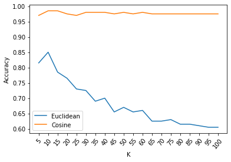

```python
k = np.array(range(5,101,5))
plt.plot(euclid,label='Euclidean')
plt.plot(cosine,label = 'Cosine')
plt.legend(loc='best')
plt.xticks(np.arange(len(k)),k,rotation = 50)
plt.xlabel('K')
plt.ylabel('Accuracy')
plt.show()
```

Once K = 10, we can really see a decline in euclidean performance. Cosine distance stays very stable over time. As discussed in class Cosine usually performs better on text classification.

d. Next, modify the training and test data sets so that term weights are converted to TFxIDF weights (instead of raw term frequencies). [See class notes on Text Categorization]. Then, rerun your evaluation (only for the Cosine similairty version of the classifier) on the range of K values (as above) and compare the results to the results without using TFxIDF weights.

```python
trainDTM
```

```
array([[2., 2., 2., ..., 0., 0., 0.],
       [0., 0., 0., ..., 0., 0., 0.],
       [0., 0., 0., ..., 0., 0., 0.],
       ...,
       [0., 0., 0., ..., 0., 0., 0.],
       [0., 0., 0., ..., 0., 0., 0.],
       [0., 0., 0., ..., 0., 0., 0.]])
```

```python
testDTM
```

```
array([[0., 0., 0., ..., 0., 0., 0.],
       [0., 0., 0., ..., 0., 0., 0.],
       [1., 0., 0., ..., 0., 0., 0.],
       ...,
       [0., 0., 0., ..., 0., 0., 0.],
       [0., 0., 0., ..., 0., 0., 0.],
       [0., 0., 0., ..., 0., 0., 0.]])
```

```python
train_matrix.head()
```

|  | 0 | 1 | 2 | 3 | 4 | 5 | 6 | 7 | 8 | 9 | ... | 790 | 791 | 792 | 793 | 794 | 795 | 796 | 797 | 798 | 799 |
| --- | --- | --- | --- | --- | --- | --- | --- | --- | --- | --- | --- | --- | --- | --- | --- | --- | --- | --- | --- | --- | --- |
| 0 | 2.0 | 0.0 | 0.0 | 2.0 | 2.0 | 0.0 | 0.0 | 0.0 | 0.0 | 0.0 | ... | 0.0 | 0.0 | 0.0 | 0.0 | 0.0 | 0.0 | 0.0 | 0.0 | 0.0 | 0.0 |
| 1 | 2.0 | 0.0 | 0.0 | 0.0 | 0.0 | 0.0 | 0.0 | 0.0 | 0.0 | 0.0 | ... | 0.0 | 0.0 | 3.0 | 0.0 | 0.0 | 0.0 | 0.0 | 0.0 | 0.0 | 0.0 |
| 2 | 2.0 | 0.0 | 0.0 | 0.0 | 0.0 | 0.0 | 0.0 | 0.0 | 0.0 | 0.0 | ... | 0.0 | 0.0 | 0.0 | 0.0 | 0.0 | 0.0 | 0.0 | 0.0 | 0.0 | 0.0 |
| 3 | 1.0 | 1.0 | 1.0 | 1.0 | 1.0 | 1.0 | 2.0 | 1.0 | 1.0 | 1.0 | ... | 1.0 | 1.0 | 1.0 | 1.0 | 1.0 | 1.0 | 1.0 | 1.0 | 1.0 | 1.0 |
| 4 | 8.0 | 1.0 | 0.0 | 0.0 | 0.0 | 0.0 | 0.0 | 0.0 | 0.0 | 0.0 | ... | 0.0 | 0.0 | 2.0 | 0.0 | 0.0 | 0.0 | 0.0 | 0.0 | 0.0 | 1.0 |

5 rows × 800 columns

```python
test_matrix.head()
```

|  | 0 | 1 | 2 | 3 | 4 | 5 | 6 | 7 | 8 | 9 | ... | 190 | 191 | 192 | 193 | 194 | 195 | 196 | 197 | 198 | 199 |
| --- | --- | --- | --- | --- | --- | --- | --- | --- | --- | --- | --- | --- | --- | --- | --- | --- | --- | --- | --- | --- | --- |
| 0 | 0.0 | 0.0 | 1.0 | 0.0 | 0.0 | 0.0 | 0.0 | 0.0 | 0.0 | 0.0 | ... | 0.0 | 0.0 | 0.0 | 0.0 | 0.0 | 0.0 | 0.0 | 0.0 | 0.0 | 0.0 |
| 1 | 0.0 | 0.0 | 0.0 | 0.0 | 0.0 | 0.0 | 0.0 | 0.0 | 0.0 | 0.0 | ... | 0.0 | 0.0 | 0.0 | 0.0 | 0.0 | 0.0 | 0.0 | 0.0 | 0.0 | 0.0 |
| 2 | 0.0 | 0.0 | 0.0 | 0.0 | 0.0 | 0.0 | 0.0 | 0.0 | 0.0 | 0.0 | ... | 0.0 | 0.0 | 0.0 | 0.0 | 0.0 | 0.0 | 0.0 | 0.0 | 0.0 | 0.0 |
| 3 | 1.0 | 1.0 | 1.0 | 1.0 | 1.0 | 1.0 | 2.0 | 1.0 | 1.0 | 1.0 | ... | 1.0 | 2.0 | 1.0 | 1.0 | 1.0 | 1.0 | 1.0 | 1.0 | 1.0 | 1.0 |
| 4 | 0.0 | 0.0 | 0.0 | 0.0 | 0.0 | 0.0 | 0.0 | 0.0 | 2.0 | 0.0 | ... | 0.0 | 0.0 | 0.0 | 0.0 | 0.0 | 0.0 | 0.0 | 0.0 | 0.0 | 0.0 |

5 rows × 200 columns

```python
train_matrix.shape
```

```
(5500, 800)
```

```python
train_docs = train_matrix.shape[0]
```

```python
test_docs = test_matrix.shape[0]
```

```python
train_termsFreq = train_matrix.sum(axis = 1)
train_termsFreq
```

```
0       102.0
1        11.0
2        22.0
3       959.0
4       222.0
        ...
5495      3.0
5496      3.0
5497      2.0
5498      2.0
5499      2.0
Length: 5500, dtype: float64
```

```python
test_matrix.shape
```

```
(5500, 200)
```

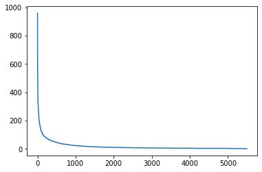

```python
plt.plot(sorted(train_termsFreq,reverse = True))
plt.show()
```

```python
DF_train = pd.DataFrame([(train_matrix!=0).sum(1)]).T
DF_train
```

|  | 0 |
| --- | --- |
| 0 | 50 |
| 1 | 7 |
| 2 | 10 |
| 3 | 800 |
| 4 | 108 |
| ... | ... |
| 5495 | 3 |
| 5496 | 3 |
| 5497 | 2 |
| 5498 | 2 |
| 5499 | 2 |

5500 rows × 1 columns

```python
NMatrix_train = np.ones(np.shape(train_matrix), dtype=float)*train_docs
np.set_printoptions(precision=2,suppress=True,linewidth=120)
print(NMatrix_train)
```

```
[[5500. 5500. 5500. ... 5500. 5500. 5500.]
 [5500. 5500. 5500. ... 5500. 5500. 5500.]
 [5500. 5500. 5500. ... 5500. 5500. 5500.]
 ...
 [5500. 5500. 5500. ... 5500. 5500. 5500.]
 [5500. 5500. 5500. ... 5500. 5500. 5500.]
 [5500. 5500. 5500. ... 5500. 5500. 5500.]]
```

```python
NMatrix_test = np.ones(np.shape(test_matrix), dtype=float)*train_docs
np.set_printoptions(precision=2,suppress=True,linewidth=120)
print(NMatrix_test)
```

```
[[5500. 5500. 5500. ... 5500. 5500. 5500.]
 [5500. 5500. 5500. ... 5500. 5500. 5500.]
 [5500. 5500. 5500. ... 5500. 5500. 5500.]
 ...
 [5500. 5500. 5500. ... 5500. 5500. 5500.]
 [5500. 5500. 5500. ... 5500. 5500. 5500.]
 [5500. 5500. 5500. ... 5500. 5500. 5500.]]
```

```python
#IDF values
IDF_train=np.log2(np.divide(NMatrix_train, np.array(DF_train)))
IDF_train
```

```
array([[ 6.78,  6.78,  6.78, ...,  6.78,  6.78,  6.78],
       [ 9.62,  9.62,  9.62, ...,  9.62,  9.62,  9.62],
       [ 9.1 ,  9.1 ,  9.1 , ...,  9.1 ,  9.1 ,  9.1 ],
       ...,
       [11.43, 11.43, 11.43, ..., 11.43, 11.43, 11.43],
       [11.43, 11.43, 11.43, ..., 11.43, 11.43, 11.43],
       [11.43, 11.43, 11.43, ..., 11.43, 11.43, 11.43]])
```

```python
IDF_test = np.log2(np.divide(NMatrix_test, np.array(DF_train)))
IDF_test
```

```
array([[ 6.78,  6.78,  6.78, ...,  6.78,  6.78,  6.78],
       [ 9.62,  9.62,  9.62, ...,  9.62,  9.62,  9.62],
       [ 9.1 ,  9.1 ,  9.1 , ...,  9.1 ,  9.1 ,  9.1 ],
       ...,
       [11.43, 11.43, 11.43, ..., 11.43, 11.43, 11.43],
       [11.43, 11.43, 11.43, ..., 11.43, 11.43, 11.43],
       [11.43, 11.43, 11.43, ..., 11.43, 11.43, 11.43]])
```

```python
TD_IDF_train = train_matrix*IDF_train
TD_IDF_train.head()
```

|  | 0 | 1 | 2 | 3 | 4 | 5 | 6 | 7 | 8 | 9 | ... | 790 | 791 | 792 | 793 | 794 | 795 | 796 | 797 | 798 | 799 |
| --- | --- | --- | --- | --- | --- | --- | --- | --- | --- | --- | --- | --- | --- | --- | --- | --- | --- | --- | --- | --- | --- |
| 0 | 13.562719 | 0.000000 | 0.00000 | 13.562719 | 13.562719 | 0.00000 | 0.000000 | 0.00000 | 0.00000 | 0.00000 | ... | 0.00000 | 0.00000 | 0.000000 | 0.00000 | 0.00000 | 0.00000 | 0.00000 | 0.00000 | 0.00000 | 0.000000 |
| 1 | 19.235722 | 0.000000 | 0.00000 | 0.000000 | 0.000000 | 0.00000 | 0.000000 | 0.00000 | 0.00000 | 0.00000 | ... | 0.00000 | 0.00000 | 28.853583 | 0.00000 | 0.00000 | 0.00000 | 0.00000 | 0.00000 | 0.00000 | 0.000000 |
| 2 | 18.206576 | 0.000000 | 0.00000 | 0.000000 | 0.000000 | 0.00000 | 0.000000 | 0.00000 | 0.00000 | 0.00000 | ... | 0.00000 | 0.00000 | 0.000000 | 0.00000 | 0.00000 | 0.00000 | 0.00000 | 0.00000 | 0.00000 | 0.000000 |
| 3 | 2.781360 | 2.781360 | 2.78136 | 2.781360 | 2.781360 | 2.78136 | 5.562719 | 2.78136 | 2.78136 | 2.78136 | ... | 2.78136 | 2.78136 | 2.781360 | 2.78136 | 2.78136 | 2.78136 | 2.78136 | 2.78136 | 2.78136 | 2.781360 |
| 4 | 45.362627 | 5.670328 | 0.00000 | 0.000000 | 0.000000 | 0.00000 | 0.000000 | 0.00000 | 0.00000 | 0.00000 | ... | 0.00000 | 0.00000 | 11.340657 | 0.00000 | 0.00000 | 0.00000 | 0.00000 | 0.00000 | 0.00000 | 5.670328 |

5 rows × 800 columns

```python
TD_IDF_test = test_matrix*IDF_test
TD_IDF_test.head()
```

|  | 0 | 1 | 2 | 3 | 4 | 5 | 6 | 7 | 8 | 9 | ... | 190 | 191 | 192 | 193 | 194 | 195 | 196 | 197 | 198 | 199 |
| --- | --- | --- | --- | --- | --- | --- | --- | --- | --- | --- | --- | --- | --- | --- | --- | --- | --- | --- | --- | --- | --- |
| 0 | 0.00000 | 0.00000 | 6.78136 | 0.00000 | 0.00000 | 0.00000 | 0.000000 | 0.00000 | 0.000000 | 0.00000 | ... | 0.00000 | 0.000000 | 0.00000 | 0.00000 | 0.00000 | 0.00000 | 0.00000 | 0.00000 | 0.00000 | 0.00000 |
| 1 | 0.00000 | 0.00000 | 0.00000 | 0.00000 | 0.00000 | 0.00000 | 0.000000 | 0.00000 | 0.000000 | 0.00000 | ... | 0.00000 | 0.000000 | 0.00000 | 0.00000 | 0.00000 | 0.00000 | 0.00000 | 0.00000 | 0.00000 | 0.00000 |
| 2 | 0.00000 | 0.00000 | 0.00000 | 0.00000 | 0.00000 | 0.00000 | 0.000000 | 0.00000 | 0.000000 | 0.00000 | ... | 0.00000 | 0.000000 | 0.00000 | 0.00000 | 0.00000 | 0.00000 | 0.00000 | 0.00000 | 0.00000 | 0.00000 |
| 3 | 2.78136 | 2.78136 | 2.78136 | 2.78136 | 2.78136 | 2.78136 | 5.562719 | 2.78136 | 2.781360 | 2.78136 | ... | 2.78136 | 5.562719 | 2.78136 | 2.78136 | 2.78136 | 2.78136 | 2.78136 | 2.78136 | 2.78136 | 2.78136 |
| 4 | 0.00000 | 0.00000 | 0.00000 | 0.00000 | 0.00000 | 0.00000 | 0.000000 | 0.00000 | 11.340657 | 0.00000 | ... | 0.00000 | 0.000000 | 0.00000 | 0.00000 | 0.00000 | 0.00000 | 0.00000 | 0.00000 | 0.00000 | 0.00000 |

5 rows × 200 columns

```python
TD_IDF_trainT = np.array(TD_IDF_train.T)
TD_IDF_testT = np.array(TD_IDF_test.T)
#TD_IDF_trainT = TD_IDF_train.T
#TD_IDF_testT = TD_IDF_test.T
```

```python
TD_IDF_trainT.shape
```

```
(800, 5500)
```

```python
TD_IDF_testT.shape
```

```
(200, 5500)
```

```python
print(testDTM.shape)
print(trainDTM.shape)
testDTM
```

```
(200, 5500)
(800, 5500)
```

```
array([[0., 0., 0., ..., 0., 0., 0.],
       [0., 0., 0., ..., 0., 0., 0.],
       [1., 0., 0., ..., 0., 0., 0.],
       ...,
       [0., 0., 0., ..., 0., 0., 0.],
       [0., 0., 0., ..., 0., 0., 0.],
       [0., 0., 0., ..., 0., 0., 0.]])
```

```python
print(TD_IDF_testT.shape)
print(TD_IDF_trainT.shape)
TD_IDF_testT
```

```
(200, 5500)
(800, 5500)
```

```
array([[0.  , 0.  , 0.  , ..., 0.  , 0.  , 0.  ],
       [0.  , 0.  , 0.  , ..., 0.  , 0.  , 0.  ],
       [6.78, 0.  , 0.  , ..., 0.  , 0.  , 0.  ],
       ...,
       [0.  , 0.  , 0.  , ..., 0.  , 0.  , 0.  ],
       [0.  , 0.  , 0.  , ..., 0.  , 0.  , 0.  ],
       [0.  , 0.  , 0.  , ..., 0.  , 0.  , 0.  ]])
```

```python
%%time
cosine_IDF=[]
for K in range(5,101,5):
    acc_cosineIDF = knn_evaluate(TD_IDF_testT,test_classesNameDTM,TD_IDF_trainT,train_classesNameDTM,K,1)
    cosine_IDF.append(acc_cosineIDF)
print(cosine_IDF)
print(len(cosine_IDF))
```

```
Labels for top  5 neighbors:  [('Hockey', 5)]
Predicted Label:  Hockey ==> Actual Label:  Hockey

Labels for top  5 neighbors:  [('Windows', 5)]
Predicted Label:  Windows ==> Actual Label:  Windows

Labels for top  5 neighbors:  [('Windows', 5)]
Predicted Label:  Windows ==> Actual Label:  Windows

Labels for top  5 neighbors:  [('Hockey', 5)]
Predicted Label:  Hockey ==> Actual Label:  Hockey

Labels for top  5 neighbors:  [('Hockey', 5)]
Predicted Label:  Hockey ==> Actual Label:  Hockey

Labels for top  5 neighbors:  [('Windows', 5)]
Predicted Label:  Windows ==> Actual Label:  Windows

Labels for top  5 neighbors:  [('Hockey', 5)]
Predicted Label:  Hockey ==> Actual Label:  Hockey

Labels for top  5 neighbors:  [('Hockey', 4), ('Windows', 1)]
Predicted Label:  Hockey ==> Actual Label:  Hockey

Labels for top  5 neighbors:  [('Windows', 5)]
Predicted Label:  Windows ==> Actual Label:  Windows

Labels for top  5 neighbors:  [('Hockey', 5)]
Predicted Label:  Hockey ==> Actual Label:  Hockey

Labels for top  5 neighbors:  [('Windows', 5)]
Predicted Label:  Windows ==> Actual Label:  Windows

Labels for top  5 neighbors:  [('Hockey', 5)]
Predicted Label:  Hockey ==> Actual Label:  Hockey

Labels for top  5 neighbors:  [('Windows', 5)]
Predicted Label:  Windows ==> Actual Label:  Windows

Labels for top  5 neighbors:  [('Windows', 5)]
```

[output cut: 11948 more lines]

```
Labels for top  100 neighbors:  [('Hockey', 100)]
Predicted Label:  Hockey ==> Actual Label:  Hockey

Labels for top  100 neighbors:  [('Windows', 100)]
Predicted Label:  Windows ==> Actual Label:  Windows

Labels for top  100 neighbors:  [('Hockey', 99), ('Windows', 1)]
Predicted Label:  Hockey ==> Actual Label:  Hockey

Labels for top  100 neighbors:  [('Hockey', 89), ('Windows', 11)]
Predicted Label:  Hockey ==> Actual Label:  Hockey

[0.975, 0.995, 0.995, 0.995, 0.99, 0.995, 0.98, 0.98, 0.985, 0.99, 0.985, 0.985, 0.985, 0.985, 0.985, 0.985, 0.985, 0.985, 0.99, 0.99]
20
Wall time: 2min 46s
```

```python
print(cosine)
print()
print(cosine_IDF)
```

```
[0.97, 0.985, 0.985, 0.975, 0.97, 0.98, 0.98, 0.98, 0.975, 0.98, 0.975, 0.98, 0.975, 0.975, 0.975, 0.975, 0.975, 0.975, 0.975, 0.975]

[0.975, 0.995, 0.995, 0.995, 0.99, 0.995, 0.98, 0.98, 0.985, 0.99, 0.985, 0.985, 0.985, 0.985, 0.985, 0.985, 0.985, 0.985, 0.99, 0.99]
```

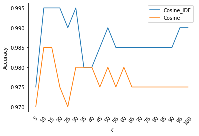

```python
k = np.array(range(5,101,5))
plt.plot(cosine_IDF,label = 'Cosine_IDF')
plt.plot(cosine,label = 'Cosine')
plt.legend(loc='best')
plt.xticks(np.arange(len(k)),k,rotation = 50)
plt.xlabel('K')
plt.ylabel('Accuracy')
plt.show()
```

From the above plot, we can see that the Cosine_IDF performs slighlty better. It is higher or equal at all values of K.

e. Create a new classifier based on the **Rocchio Method** adapted for text categorization [See class notes on Text Categorization].

I. You should separate the training function from the classifiation function

II. The training part for the classifier can be implemented as a function that takes as input the training data matrix and the training labels, returning the prototype vectors for each class

III. The classification part can be implemented as another function that would take as input the prototypes returned from the training function and the instance to be classified

IV. This function should measure Cosine similarity of the test instance to each prototype vector

V. Your output should indicate the predicted class for the test instance and the similarity values of the instance to each of the category prototypes.

VI. Finally, use your evaluation function to compare your results to the best KNN results you obtained in part d. [Note: your functions should work regardless of the number of categories (class labels) and should not be limited to two-class categorization scenario.]

```python
def Rocchio_Train(train,labels):
    proto= {}
    for a,b in zip(train,labels.T):
        proto[b] = a
    return proto
    #print(sum(proto['Windows']))
    #print(sum(proto['Hockey']))
Rocchio_Train(TD_IDF_trainT,train_classesNameDTM)
```

```
{'Windows': array([0., 0., 0., ..., 0., 0., 0.]),
 'Hockey': array([0., 0., 0., ..., 0., 0., 0.])}
```

```python
proto = Rocchio_Train(TD_IDF_trainT,train_classesNameDTM)
def Rocchio_classify(protoypes, instance):
    #set up for max cosine
    cls = -1
    p = -1
    #cosine sim
    for i,j in proto.items():
        sim = np.dot(instance,j)/(np.linalg.norm(instance)*np.linalg.norm(j))
        if sim>p:
            p = sim
            cls = i #update most similar
    return cls
Rocchio_classify(proto,TD_IDF_testT[0])
```

```
'Hockey'
```

```python
proto = Rocchio_Train(TD_IDF_trainT,train_classesNameDTM)
def Rocchio_evaluate(test,prototypes,labels):
    numtestvec = len(test)
    correct = 0
    for r in range(len(test)):
        pred_rocchio = Rocchio_classify(proto,TD_IDF_testT[r])
        if pred_rocchio == test_classesNameDTM[r]:
            correct+=1
    return correct,correct/numtestvec,numtestvec

Rocchio_evaluate(TD_IDF_testT,proto,test_classesNameDTM)
```

```
(148, 0.74, 200)
```

```python
print(np.average(cosine_IDF))
```

```
0.9869999999999998
```

Our best average was 98.7% with the IDF KNN classifier. This is better than our rocchio method which performs at 74% accuracy.

**Question 2**

For this problem you will experiment with various classifiers provided as part of the scikit-learn (sklearn) machine learning module, as well as with some of its preprocessing and model evaluation capabilities. [Note: This module is already part of the Anaconda distributions. You will work with a modified subset of a real data set of customers for a bank. This is the same data set used in Assignment 1. The data is provided in a CSV formatted file with the first row containing the attribute names. The description of the the different fields in the data are provided in this document. Your tasks in this problem are the following:

a. Load and preprocess the data using Pandas or similar tools. Specifically, you need to separate the target attribute ("pep") from the portion of the data to be used for training and testing. You will need to convert the selected dataset into the Standard Spreadsheet format (i.e., convert categorical attributes into numeric by creating dummy variables). Finally, split the transformed data into training and test sets (using 80%-20% randomized split). [Review Jupyter Notebooks from class to see examples of how to perform these tasks.]

```python
import os
import pandas as pd
import numpy as np
import matplotlib.pyplot as plt
%matplotlib inline
```

```python
bank = pd.read_csv('bank_data.csv', index_col = 0)
bank.head()
```

| id | age | income | children | gender | region | married | car | savings_acct | current_acct | mortgage | pep |
| --- | --- | --- | --- | --- | --- | --- | --- | --- | --- | --- | --- |
| ID12101 | 48 | 17546.0 | 1 | FEMALE | INNER_CITY | NO | NO | NO | NO | NO | YES |
| ID12102 | 40 | 30085.1 | 3 | MALE | TOWN | YES | YES | NO | YES | YES | NO |
| ID12103 | 51 | 16575.4 | 0 | FEMALE | INNER_CITY | YES | YES | YES | YES | NO | NO |
| ID12104 | 23 | 20375.4 | 3 | FEMALE | TOWN | YES | NO | NO | YES | NO | NO |
| ID12105 | 57 | 50576.3 | 0 | FEMALE | RURAL | YES | NO | YES | NO | NO | NO |

```python
bank.shape
```

```
(600, 11)
```

**Separate target value "pep"**

```python
bank_X = bank[['age','income','children','gender','region','married','car','savings_acct','current_acct','mortgage']]
bank_X.head()
```

| id | age | income | children | gender | region | married | car | savings_acct | current_acct | mortgage |
| --- | --- | --- | --- | --- | --- | --- | --- | --- | --- | --- |
| ID12101 | 48 | 17546.0 | 1 | FEMALE | INNER_CITY | NO | NO | NO | NO | NO |
| ID12102 | 40 | 30085.1 | 3 | MALE | TOWN | YES | YES | NO | YES | YES |
| ID12103 | 51 | 16575.4 | 0 | FEMALE | INNER_CITY | YES | YES | YES | YES | NO |
| ID12104 | 23 | 20375.4 | 3 | FEMALE | TOWN | YES | NO | NO | YES | NO |
| ID12105 | 57 | 50576.3 | 0 | FEMALE | RURAL | YES | NO | YES | NO | NO |

```python
bank_y = bank.pep
bank_y.head()
```

```
id
ID12101    YES
ID12102     NO
ID12103     NO
ID12104     NO
ID12105     NO
Name: pep, dtype: object
```

**Use "get_dummies" function**

```python
bank_Xmatrix = pd.get_dummies(bank_X[['age','income','children','gender','region','married','car','savings_acct','current_acct','mortgage']])
bank_Xmatrix.head()
```

| id | age | income | children | gender_FEMALE | gender_MALE | region_INNER_CITY | region_RURAL | region_SUBURBAN | region_TOWN | married_NO | married_YES | car_NO | car_YES | savings_acct_NO | savings_acct_YES | current_acct_NO | current_acct_YES | mortgage_NO | mortgage_YES |
| --- | --- | --- | --- | --- | --- | --- | --- | --- | --- | --- | --- | --- | --- | --- | --- | --- | --- | --- | --- |
| ID12101 | 48 | 17546.0 | 1 | 1 | 0 | 1 | 0 | 0 | 0 | 1 | 0 | 1 | 0 | 1 | 0 | 1 | 0 | 1 | 0 |
| ID12102 | 40 | 30085.1 | 3 | 0 | 1 | 0 | 0 | 0 | 1 | 0 | 1 | 0 | 1 | 1 | 0 | 0 | 1 | 0 | 1 |
| ID12103 | 51 | 16575.4 | 0 | 1 | 0 | 1 | 0 | 0 | 0 | 0 | 1 | 0 | 1 | 0 | 1 | 0 | 1 | 1 | 0 |
| ID12104 | 23 | 20375.4 | 3 | 1 | 0 | 0 | 0 | 0 | 1 | 0 | 1 | 1 | 0 | 1 | 0 | 0 | 1 | 1 | 0 |
| ID12105 | 57 | 50576.3 | 0 | 1 | 0 | 0 | 1 | 0 | 0 | 0 | 1 | 1 | 0 | 0 | 1 | 1 | 0 | 1 | 0 |

**Next, we divide the data into randomized training and test partitions (note that the same split should also be perfromed on the target attribute). The easiest way to do this is to use the "train_test_split" module of "sklearn.cross_validation".**

```python
from sklearn.model_selection import train_test_split
bank_Xtrain, bank_Xtest, bank_yTrain, bank_yTest = train_test_split(bank_Xmatrix,bank_y, test_size=0.2, random_state=33)

print(bank_Xtest.shape)
bank_Xtest[0:5]
```

```
(120, 19)
```

| id | age | income | children | gender_FEMALE | gender_MALE | region_INNER_CITY | region_RURAL | region_SUBURBAN | region_TOWN | married_NO | married_YES | car_NO | car_YES | savings_acct_NO | savings_acct_YES | current_acct_NO | current_acct_YES | mortgage_NO | mortgage_YES |
| --- | --- | --- | --- | --- | --- | --- | --- | --- | --- | --- | --- | --- | --- | --- | --- | --- | --- | --- | --- |
| ID12557 | 32 | 13267.6 | 0 | 1 | 0 | 0 | 0 | 0 | 1 | 0 | 1 | 0 | 1 | 0 | 1 | 0 | 1 | 0 | 1 |
| ID12467 | 59 | 29866.9 | 1 | 1 | 0 | 1 | 0 | 0 | 0 | 1 | 0 | 0 | 1 | 1 | 0 | 0 | 1 | 1 | 0 |
| ID12232 | 61 | 41609.5 | 3 | 0 | 1 | 0 | 1 | 0 | 0 | 0 | 1 | 1 | 0 | 0 | 1 | 0 | 1 | 0 | 1 |
| ID12549 | 53 | 48971.6 | 3 | 0 | 1 | 0 | 1 | 0 | 0 | 0 | 1 | 0 | 1 | 0 | 1 | 1 | 0 | 1 | 0 |
| ID12438 | 65 | 38080.9 | 1 | 0 | 1 | 1 | 0 | 0 | 0 | 0 | 1 | 0 | 1 | 0 | 1 | 1 | 0 | 0 | 1 |

```python
print(bank_Xtrain.shape)
bank_Xtrain[0:5]
```

```
(480, 19)
```

| id | age | income | children | gender_FEMALE | gender_MALE | region_INNER_CITY | region_RURAL | region_SUBURBAN | region_TOWN | married_NO | married_YES | car_NO | car_YES | savings_acct_NO | savings_acct_YES | current_acct_NO | current_acct_YES | mortgage_NO | mortgage_YES |
| --- | --- | --- | --- | --- | --- | --- | --- | --- | --- | --- | --- | --- | --- | --- | --- | --- | --- | --- | --- |
| ID12482 | 46 | 32583.5 | 2 | 1 | 0 | 1 | 0 | 0 | 0 | 0 | 1 | 0 | 1 | 0 | 1 | 0 | 1 | 1 | 0 |
| ID12105 | 57 | 50576.3 | 0 | 1 | 0 | 0 | 1 | 0 | 0 | 0 | 1 | 1 | 0 | 0 | 1 | 1 | 0 | 1 | 0 |
| ID12187 | 25 | 15525.0 | 0 | 1 | 0 | 1 | 0 | 0 | 0 | 0 | 1 | 1 | 0 | 0 | 1 | 0 | 1 | 1 | 0 |
| ID12184 | 35 | 16394.4 | 1 | 0 | 1 | 1 | 0 | 0 | 0 | 0 | 1 | 1 | 0 | 0 | 1 | 0 | 1 | 1 | 0 |
| ID12624 | 34 | 16291.0 | 0 | 1 | 0 | 0 | 0 | 0 | 1 | 0 | 1 | 0 | 1 | 0 | 1 | 1 | 0 | 0 | 1 |

b. Run scikit-learn's KNN classifier on the test set. Note: in the case of KNN, you should first normalize the data so that all attributes are in the same scale (normalize so that the values are between 0 and 1).

Generate the confusion matrix (visualize it using Matplotlib), as well as the classification report.

Experiment with different **values of K and the weight parameter** (i.e., with or without distance weighting) for KNN to see if you can improve accuracy (you do not need to provide the details of all of your experimentation, but provide a short discussion on what parameters worked best as well as your final results).

**Normalize first**

```python
from sklearn import preprocessing
```

```python
min_max_scaler = preprocessing.MinMaxScaler().fit(bank_Xtrain)

bank_Xtrain_norm = min_max_scaler.transform(bank_Xtrain)
bank_Xtrain_norm = pd.DataFrame(bank_Xtrain_norm,columns = bank_Xtrain.columns,index = bank_Xtrain.index)

bank_Xtest_norm = min_max_scaler.transform(bank_Xtest)
bank_Xtest_norm = pd.DataFrame(bank_Xtest_norm,columns = bank_Xtest.columns,index = bank_Xtest.index)
```

```python
bank_Xtrain_norm.head()
```

| id | age | income | children | gender_FEMALE | gender_MALE | region_INNER_CITY | region_RURAL | region_SUBURBAN | region_TOWN | married_NO | married_YES | car_NO | car_YES | savings_acct_NO | savings_acct_YES | current_acct_NO | current_acct_YES | mortgage_NO | mortgage_YES |
| --- | --- | --- | --- | --- | --- | --- | --- | --- | --- | --- | --- | --- | --- | --- | --- | --- | --- | --- | --- |
| ID12482 | 0.571429 | 0.462547 | 0.666667 | 1.0 | 0.0 | 1.0 | 0.0 | 0.0 | 0.0 | 0.0 | 1.0 | 0.0 | 1.0 | 0.0 | 1.0 | 0.0 | 1.0 | 1.0 | 0.0 |
| ID12105 | 0.795918 | 0.779122 | 0.000000 | 1.0 | 0.0 | 0.0 | 1.0 | 0.0 | 0.0 | 0.0 | 1.0 | 1.0 | 0.0 | 0.0 | 1.0 | 1.0 | 0.0 | 1.0 | 0.0 |
| ID12187 | 0.142857 | 0.162411 | 0.000000 | 1.0 | 0.0 | 1.0 | 0.0 | 0.0 | 0.0 | 0.0 | 1.0 | 1.0 | 0.0 | 0.0 | 1.0 | 0.0 | 1.0 | 1.0 | 0.0 |
| ID12184 | 0.346939 | 0.177708 | 0.333333 | 0.0 | 1.0 | 1.0 | 0.0 | 0.0 | 0.0 | 0.0 | 1.0 | 1.0 | 0.0 | 0.0 | 1.0 | 0.0 | 1.0 | 1.0 | 0.0 |
| ID12624 | 0.326531 | 0.175889 | 0.000000 | 1.0 | 0.0 | 0.0 | 0.0 | 0.0 | 1.0 | 0.0 | 1.0 | 0.0 | 1.0 | 0.0 | 1.0 | 1.0 | 0.0 | 0.0 | 1.0 |

```python
bank_Xtest_norm.head()
```

| id | age | income | children | gender_FEMALE | gender_MALE | region_INNER_CITY | region_RURAL | region_SUBURBAN | region_TOWN | married_NO | married_YES | car_NO | car_YES | savings_acct_NO | savings_acct_YES | current_acct_NO | current_acct_YES | mortgage_NO | mortgage_YES |
| --- | --- | --- | --- | --- | --- | --- | --- | --- | --- | --- | --- | --- | --- | --- | --- | --- | --- | --- | --- |
| ID12557 | 0.285714 | 0.122693 | 0.000000 | 1.0 | 0.0 | 0.0 | 0.0 | 0.0 | 1.0 | 0.0 | 1.0 | 0.0 | 1.0 | 0.0 | 1.0 | 0.0 | 1.0 | 0.0 | 1.0 |
| ID12467 | 0.836735 | 0.414750 | 0.333333 | 1.0 | 0.0 | 1.0 | 0.0 | 0.0 | 0.0 | 1.0 | 0.0 | 0.0 | 1.0 | 1.0 | 0.0 | 0.0 | 1.0 | 1.0 | 0.0 |
| ID12232 | 0.877551 | 0.621355 | 1.000000 | 0.0 | 1.0 | 0.0 | 1.0 | 0.0 | 0.0 | 0.0 | 1.0 | 1.0 | 0.0 | 0.0 | 1.0 | 0.0 | 1.0 | 0.0 | 1.0 |
| ID12549 | 0.714286 | 0.750888 | 1.000000 | 0.0 | 1.0 | 0.0 | 1.0 | 0.0 | 0.0 | 0.0 | 1.0 | 0.0 | 1.0 | 0.0 | 1.0 | 1.0 | 0.0 | 1.0 | 0.0 |
| ID12438 | 0.959184 | 0.559271 | 0.333333 | 0.0 | 1.0 | 1.0 | 0.0 | 0.0 | 0.0 | 0.0 | 1.0 | 0.0 | 1.0 | 0.0 | 1.0 | 1.0 | 0.0 | 0.0 | 1.0 |

```python
from sklearn import neighbors, tree, naive_bayes
```

First, we'll use KNN classifer. You can vary K and monitor the accuracy metrics (see below) to find the best value.

```python
n_neighbors = 2

knnclf = neighbors.KNeighborsClassifier(n_neighbors, weights='distance')
knnclf.fit(bank_Xtrain_norm,bank_yTrain)#(vs_train_norm, vs_target_train)
```

```
KNeighborsClassifier(algorithm='auto', leaf_size=30, metric='minkowski',
                     metric_params=None, n_jobs=None, n_neighbors=2, p=2,
                     weights='distance')
```

```python
knnpreds_test = knnclf.predict(bank_Xtest_norm)
```

```python
print(knnpreds_test)
```

```
['YES' 'YES' 'NO' 'NO' 'YES' 'YES' 'YES' 'YES' 'NO' 'NO' 'NO' 'NO' 'YES' 'NO' 'YES' 'NO' 'YES' 'YES' 'YES' 'NO' 'YES'
 'YES' 'NO' 'NO' 'YES' 'YES' 'YES' 'NO' 'NO' 'YES' 'NO' 'NO' 'NO' 'YES' 'NO' 'YES' 'NO' 'YES' 'YES' 'NO' 'YES' 'NO'
 'YES' 'NO' 'YES' 'NO' 'YES' 'YES' 'NO' 'YES' 'NO' 'YES' 'YES' 'NO' 'YES' 'YES' 'NO' 'YES' 'NO' 'NO' 'YES' 'NO' 'YES'
 'NO' 'NO' 'NO' 'NO' 'NO' 'NO' 'YES' 'YES' 'NO' 'YES' 'NO' 'NO' 'NO' 'YES' 'YES' 'YES' 'NO' 'YES' 'YES' 'YES' 'YES'
 'NO' 'NO' 'YES' 'NO' 'NO' 'YES' 'NO' 'NO' 'NO' 'NO' 'NO' 'NO' 'YES' 'NO' 'YES' 'NO' 'NO' 'NO' 'YES' 'YES' 'NO' 'NO'
 'NO' 'NO' 'YES' 'YES' 'YES' 'YES' 'NO' 'YES' 'NO' 'YES' 'NO' 'NO' 'NO' 'NO']
```

```python
from sklearn.metrics import confusion_matrix
```

```python
'''
confusion matrix reference:

TN  FP
FN  TP
'''
knncm = confusion_matrix(bank_yTest,knnpreds_test)
print(knncm)
```

```
[[43 23]
 [21 33]]
```

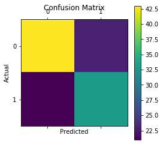

```python
import pylab as plt
plt.matshow(knncm)
plt.title('Confusion Matrix')
plt.colorbar()
plt.ylabel('Actual')
plt.xlabel('Predicted')
plt.show()
```

```python
from sklearn.metrics import classification_report
```

```python
print(classification_report(bank_yTest,knnpreds_test))
```

```
              precision    recall  f1-score   support

          NO       0.67      0.65      0.66        66
         YES       0.59      0.61      0.60        54

    accuracy                           0.63       120
   macro avg       0.63      0.63      0.63       120
weighted avg       0.63      0.63      0.63       120
```

```python
#average accuracy score across the test instances
print(knnclf.score(bank_Xtest_norm, bank_yTest))
```

```
0.6333333333333333
```

```python
#performance on training data
print(knnclf.score(bank_Xtrain_norm,bank_yTrain)) #overfit = 100% --> cannot predict the randomness
#still need to try without the weight parameter
#still need to analyze different impacts of K
```

```
1.0
```

Without Weight parameter

```python
knnclf2 = neighbors.KNeighborsClassifier(n_neighbors)#still 2 neighbors
knnclf2.fit(bank_Xtrain_norm,bank_yTrain)#(vs_train_norm, vs_target_train)
```

```
KNeighborsClassifier(algorithm='auto', leaf_size=30, metric='minkowski',
                     metric_params=None, n_jobs=None, n_neighbors=2, p=2,
                     weights='uniform')
```

```python
knnpreds_test2 = knnclf2.predict(bank_Xtest_norm)
```

```python
print(knnpreds_test2)
```

```
['NO' 'YES' 'NO' 'NO' 'YES' 'YES' 'NO' 'NO' 'NO' 'NO' 'NO' 'NO' 'NO' 'NO' 'YES' 'NO' 'YES' 'YES' 'YES' 'NO' 'NO' 'YES'
 'NO' 'NO' 'YES' 'NO' 'YES' 'NO' 'NO' 'YES' 'NO' 'NO' 'NO' 'YES' 'NO' 'YES' 'NO' 'YES' 'NO' 'NO' 'NO' 'NO' 'NO' 'NO'
 'YES' 'NO' 'YES' 'NO' 'NO' 'YES' 'NO' 'YES' 'NO' 'NO' 'YES' 'YES' 'NO' 'YES' 'NO' 'NO' 'NO' 'NO' 'NO' 'NO' 'NO' 'NO'
 'NO' 'NO' 'NO' 'YES' 'NO' 'NO' 'YES' 'NO' 'NO' 'NO' 'NO' 'YES' 'YES' 'NO' 'YES' 'YES' 'NO' 'YES' 'NO' 'NO' 'NO' 'NO'
 'NO' 'YES' 'NO' 'NO' 'NO' 'NO' 'NO' 'NO' 'YES' 'NO' 'NO' 'NO' 'NO' 'NO' 'YES' 'NO' 'NO' 'NO' 'NO' 'NO' 'NO' 'YES'
 'YES' 'NO' 'NO' 'NO' 'NO' 'NO' 'NO' 'NO' 'NO' 'NO']
```

```python
knncm2 = confusion_matrix(bank_yTest,knnpreds_test2)
print(knncm2)
```

```
[[54 12]
 [33 21]]
```

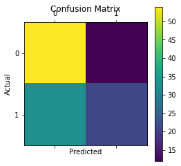

```python
import pylab as plt
plt.matshow(knncm2)
plt.title('Confusion Matrix')
plt.colorbar()
plt.ylabel('Actual')
plt.xlabel('Predicted')
plt.show()
```

```python
print(classification_report(bank_yTest,knnpreds_test))
print(classification_report(bank_yTest,knnpreds_test2))
```

```
              precision    recall  f1-score   support

          NO       0.67      0.65      0.66        66
         YES       0.59      0.61      0.60        54

    accuracy                           0.63       120
   macro avg       0.63      0.63      0.63       120
weighted avg       0.63      0.63      0.63       120

              precision    recall  f1-score   support

          NO       0.62      0.82      0.71        66
         YES       0.64      0.39      0.48        54

    accuracy                           0.62       120
   macro avg       0.63      0.60      0.59       120
weighted avg       0.63      0.62      0.61       120
```

```python
print(knnclf2.score(bank_Xtest_norm, bank_yTest))
```

```
0.625
```

```python
print(knnclf2.score(bank_Xtrain_norm,bank_yTrain))
```

```
0.8270833333333333
```

With the same amount of neighbors and no weights the accurcay dropped slightly, as well as our recall score.

Now we will try different vals of K with a distance measure.

```python
from sklearn import metrics
K_list = [1,3,5,7,10,15,20,25,30,35,40,45,50]
accuracy_train = []
accuracy_test = []
for K in K_list:
    knnclf3 = neighbors.KNeighborsClassifier(n_neighbors=K )
    knnclf3.fit(bank_Xtrain_norm,bank_yTrain)
    #train
    pred_train = knnclf3.predict(bank_Xtrain_norm)
    acc_train = metrics.accuracy_score(y_true = bank_yTrain, y_pred = pred_train)
    accuracy_train.append(acc_train)
    #test
    pred_test = knnclf3.predict(bank_Xtest_norm)
    acc_test = metrics.accuracy_score(y_true = bank_yTest,y_pred = pred_test)
    accuracy_test.append(acc_test)
```

```python
print(pred_test)
```

```
['NO' 'YES' 'NO' 'YES' 'YES' 'YES' 'NO' 'NO' 'NO' 'YES' 'NO' 'YES' 'NO' 'NO' 'NO' 'NO' 'YES' 'NO' 'YES' 'NO' 'NO' 'YES'
 'NO' 'NO' 'YES' 'NO' 'YES' 'YES' 'YES' 'NO' 'NO' 'NO' 'NO' 'NO' 'NO' 'NO' 'YES' 'YES' 'NO' 'YES' 'NO' 'NO' 'YES' 'NO'
 'YES' 'NO' 'NO' 'NO' 'NO' 'NO' 'YES' 'YES' 'YES' 'NO' 'YES' 'NO' 'YES' 'NO' 'NO' 'NO' 'YES' 'NO' 'NO' 'NO' 'NO' 'NO'
 'NO' 'NO' 'NO' 'YES' 'NO' 'YES' 'NO' 'NO' 'NO' 'YES' 'NO' 'NO' 'YES' 'NO' 'NO' 'NO' 'NO' 'NO' 'NO' 'NO' 'NO' 'NO' 'NO'
 'YES' 'NO' 'NO' 'NO' 'NO' 'YES' 'NO' 'NO' 'YES' 'NO' 'NO' 'NO' 'NO' 'NO' 'YES' 'NO' 'NO' 'YES' 'NO' 'YES' 'NO' 'YES'
 'NO' 'NO' 'YES' 'NO' 'NO' 'NO' 'NO' 'NO' 'NO']
```

```python
knncm3 = confusion_matrix(bank_yTest,pred_test)
print(knncm)
print('\n',knncm2)
print('\n',knncm3)
```

```
[[43 23]
 [21 33]]

 [[54 12]
 [33 21]]

 [[52 14]
 [32 22]]
```

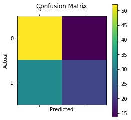

```python
import pylab as plt
plt.matshow(knncm3)
plt.title('Confusion Matrix')
plt.colorbar()
plt.ylabel('Actual')
plt.xlabel('Predicted')
plt.show()
```

```python
accuracy_train
```

```
[1.0,
 0.8104166666666667,
 0.7833333333333333,
 0.7770833333333333,
 0.76875,
 0.7354166666666667,
 0.6958333333333333,
 0.6895833333333333,
 0.6791666666666667,
 0.68125,
 0.6895833333333333,
 0.6833333333333333,
 0.6833333333333333]
```

```python
accuracy_test
```

```
[0.6333333333333333,
 0.6583333333333333,
 0.6666666666666666,
 0.65,
 0.6916666666666667,
 0.6333333333333333,
 0.6833333333333333,
 0.6916666666666667,
 0.7,
 0.6916666666666667,
 0.6666666666666666,
 0.6416666666666667,
 0.6166666666666667]
```

[figure not shown]

```python
plt.plot(accuracy_train,label='Training')
plt.plot(accuracy_test,label = 'Test')
plt.legend(loc='best')
plt.xticks(np.arange(len(K_list)),K_list,rotation =50)
plt.xlabel('K Value')
plt.ylabel('Error')
plt.show()
```

c. Using the non-normalized training and test data, perform classification using scikit-learn's decision tree classifier (using the default parameters). As above, generate the confusion matrix, classification report, and average accuracy scores the classifier. Compare the average accuracy score on the test and the training data sets. What does the comparison tell you in terms of bias-variance trade-off?

Decision tree with non normalized data set

```python
#https://scikit-learn.org/stable/modules/generated/sklearn.tree.DecisionTreeClassifier.html --> default param--> 'gini',2
treeclf = tree.DecisionTreeClassifier(criterion='gini', min_samples_split=2)
```

```python
treeclf = treeclf.fit(bank_Xtrain,bank_yTrain)
```

```python
treepreds_test = treeclf.predict(bank_Xtest)
print(treepreds_test)
```

```
['NO' 'YES' 'NO' 'YES' 'YES' 'YES' 'YES' 'YES' 'YES' 'NO' 'NO' 'YES' 'NO' 'NO' 'NO' 'NO' 'NO' 'NO' 'YES' 'NO' 'YES'
 'YES' 'NO' 'NO' 'YES' 'NO' 'YES' 'YES' 'NO' 'YES' 'NO' 'NO' 'NO' 'YES' 'NO' 'YES' 'NO' 'YES' 'NO' 'YES' 'YES' 'NO'
 'NO' 'NO' 'YES' 'NO' 'NO' 'YES' 'NO' 'YES' 'YES' 'YES' 'YES' 'YES' 'NO' 'YES' 'YES' 'YES' 'NO' 'NO' 'YES' 'NO' 'YES'
 'YES' 'YES' 'YES' 'NO' 'NO' 'YES' 'NO' 'YES' 'NO' 'NO' 'YES' 'NO' 'NO' 'NO' 'NO' 'YES' 'NO' 'NO' 'YES' 'YES' 'NO' 'NO'
 'YES' 'NO' 'NO' 'YES' 'YES' 'NO' 'NO' 'NO' 'NO' 'YES' 'NO' 'NO' 'NO' 'NO' 'NO' 'NO' 'NO' 'YES' 'YES' 'NO' 'YES' 'YES'
 'NO' 'YES' 'NO' 'YES' 'NO' 'NO' 'NO' 'NO' 'NO' 'NO' 'NO' 'NO' 'NO']
```

```python
print(treeclf.score(bank_Xtest,bank_yTest))
```

```
0.8083333333333333
```

```python
print(treeclf.score(bank_Xtrain,bank_yTrain))
```

```
1.0
```

```python
treecm = confusion_matrix(bank_yTest,treepreds_test)
print(treecm)
```

```
[[56 10]
 [13 41]]
```

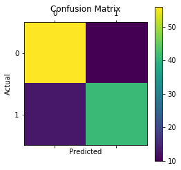

```python
import pylab as plt
plt.matshow(treecm)
plt.title('Confusion Matrix')
plt.colorbar()
plt.ylabel('Actual')
plt.xlabel('Predicted')
plt.show()
```

```python
print(classification_report(bank_yTest, treepreds_test))
```

```
              precision    recall  f1-score   support

          NO       0.81      0.85      0.83        66
         YES       0.80      0.76      0.78        54

    accuracy                           0.81       120
   macro avg       0.81      0.80      0.81       120
weighted avg       0.81      0.81      0.81       120
```

d. Create another decision tree model (trained on the non-normalized training data) using "entropy" as the selection criteria, min_samples_split=10, and max_depth=5. For this model generate a visualization of tree and submit it as a separate file (png, jpg, or pdf) or embed it in the Jupyter Notebook.

```python
treeclfENT = tree.DecisionTreeClassifier(criterion='entropy', min_samples_split=10,max_depth = 5)
```

```python
treeclfENT = treeclfENT.fit(bank_Xtrain,bank_yTrain)
```

```python
treepreds_testENT = treeclfENT.predict(bank_Xtest)
print(treepreds_testENT)
```

```
['NO' 'YES' 'NO' 'YES' 'YES' 'NO' 'YES' 'NO' 'YES' 'NO' 'NO' 'YES' 'NO' 'NO' 'NO' 'NO' 'NO' 'NO' 'YES' 'NO' 'YES' 'YES'
 'NO' 'NO' 'YES' 'NO' 'YES' 'YES' 'NO' 'YES' 'NO' 'NO' 'NO' 'YES' 'NO' 'NO' 'NO' 'YES' 'NO' 'YES' 'YES' 'NO' 'NO' 'NO'
 'YES' 'NO' 'NO' 'NO' 'NO' 'NO' 'YES' 'YES' 'YES' 'YES' 'YES' 'YES' 'YES' 'YES' 'NO' 'NO' 'YES' 'NO' 'YES' 'YES' 'YES'
 'NO' 'NO' 'NO' 'YES' 'NO' 'YES' 'NO' 'NO' 'YES' 'NO' 'NO' 'NO' 'NO' 'YES' 'NO' 'NO' 'NO' 'YES' 'NO' 'NO' 'YES' 'YES'
 'NO' 'YES' 'NO' 'NO' 'NO' 'NO' 'NO' 'YES' 'NO' 'NO' 'NO' 'NO' 'NO' 'NO' 'NO' 'YES' 'YES' 'NO' 'NO' 'NO' 'NO' 'YES'
 'NO' 'NO' 'NO' 'NO' 'NO' 'NO' 'NO' 'NO' 'NO' 'NO' 'YES']
```

```python
print(treeclfENT.score(bank_Xtest,bank_yTest))
```

```
0.7916666666666666
```

```python
print(treeclfENT.score(bank_Xtrain,bank_yTrain))
```

```
0.8666666666666667
```

```python
treecmENT = confusion_matrix(bank_yTest,treepreds_testENT)
print(treecmENT)
```

```
[[59  7]
 [18 36]]
```

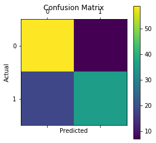

```python
import pylab as plt
plt.matshow(treecmENT)
plt.title('Confusion Matrix')
plt.colorbar()
plt.ylabel('Actual')
plt.xlabel('Predicted')
plt.show()
```

```python
print(classification_report(bank_yTest, treepreds_testENT))
```

```
              precision    recall  f1-score   support

          NO       0.77      0.89      0.83        66
         YES       0.84      0.67      0.74        54

    accuracy                           0.79       120
   macro avg       0.80      0.78      0.78       120
weighted avg       0.80      0.79      0.79       120
```

Viz of tree

```python
conda install -c anaconda graphviz python-graphviz
```

```
Solving environment: ...working... done

# All requested packages already installed.
```

```python
from sklearn.tree import export_graphviz

from IPython.display import SVG
from graphviz import Source
from IPython.display import display

tree = export_graphviz(treeclfENT, out_file=None, feature_names=bank_Xtrain.columns, class_names=['No','Yes'])
graph = Source(tree)
```

```python
display(SVG(graph.pipe(format='svg')))
```

[figure not shown]

1. Data Analysis and Predictive Modeling on Census data [Dataset: adult-modified.csv]

For this problem you will use a simplified version of the Adult Census Data Set. In the subset provided here, some of the attributes have been removed and some preprocessing has been performed.

Your tasks in this problem are the following:

a. Preprocessing and data analysis:

Examine the data for missing values. In case of categorical attributes, remove instances with missing values. In the case of numeric attributes, impute and fill-in the missing values using the attribute mean.

Examine the characteristics of the attributes, including summary statistics for the attributes, histograms illustrating the distribtions of numeric attributes, and bar graphs showing value counts for categorical attributes.

Perform the following cross-tabulations (including generating bar charts): education+race, work-class+income, work-class+race, and race+income. In the latter case (race+income) also create a table or chart showing percentages of each race category that fall in the low-income group. Discuss your observations from this analysis.

Compare and contrast the characteristics of the low-income and high-income categories across the different attributes.

```python
import os
import pandas as pd
import numpy as np
import matplotlib.pyplot as plt
%matplotlib inline
```

```python
census = pd.read_csv('adult-modified.csv')
census
```

|  | age | workclass | education | marital-status | race | sex | hours-per-week | income |
| --- | --- | --- | --- | --- | --- | --- | --- | --- |
| 0 | 39 | Public | 13 | Single | White | Male | 40 | <=50K |
| 1 | 50 | Self-emp | 13 | Married | White | Male | 13 | <=50K |
| 2 | 38 | Private | 9 | Single | White | Male | 40 | <=50K |
| 3 | 53 | Private | 7 | Married | Black | Male | 40 | <=50K |
| 4 | 28 | Private | 13 | Married | Black | Female | 40 | <=50K |
| ... | ... | ... | ... | ... | ... | ... | ... | ... |
| 9995 | 38 | Private | 10 | Married | White | Male | 60 | >50K |
| 9996 | 25 | Private | 9 | Single | White | Female | 8 | <=50K |
| 9997 | 21 | Private | 10 | Single | Black | Male | 40 | <=50K |
| 9998 | ? | Private | 2 | Married | White | Male | 53 | <=50K |
| 9999 | 39 | Private | 10 | Single | White | Female | 40 | <=50K |

10000 rows × 8 columns

Examine the data for missing values. In case of categorical attributes, remove instances with missing values. In the case of numeric attributes, impute and fill-in the missing values using the attribute mean.

Missing vals are defined with question mark. Need to change that.

```python
census_na = census.replace('?', np.NaN)
```

```python
census_na
```

|  | age | workclass | education | marital-status | race | sex | hours-per-week | income |
| --- | --- | --- | --- | --- | --- | --- | --- | --- |
| 0 | 39 | Public | 13 | Single | White | Male | 40 | <=50K |
| 1 | 50 | Self-emp | 13 | Married | White | Male | 13 | <=50K |
| 2 | 38 | Private | 9 | Single | White | Male | 40 | <=50K |
| 3 | 53 | Private | 7 | Married | Black | Male | 40 | <=50K |
| 4 | 28 | Private | 13 | Married | Black | Female | 40 | <=50K |
| ... | ... | ... | ... | ... | ... | ... | ... | ... |
| 9995 | 38 | Private | 10 | Married | White | Male | 60 | >50K |
| 9996 | 25 | Private | 9 | Single | White | Female | 8 | <=50K |
| 9997 | 21 | Private | 10 | Single | Black | Male | 40 | <=50K |
| 9998 | NaN | Private | 2 | Married | White | Male | 53 | <=50K |
| 9999 | 39 | Private | 10 | Single | White | Female | 40 | <=50K |

10000 rows × 8 columns

```python
census_na.isna().sum()
```

```
age               198
workclass         588
education           0
marital-status      0
race                0
sex                 0
hours-per-week      0
income              0
dtype: int64
```

```python
census_na.info()
```

```
<class 'pandas.core.frame.DataFrame'>
RangeIndex: 10000 entries, 0 to 9999
Data columns (total 8 columns):
age               9802 non-null object
workclass         9412 non-null object
education         10000 non-null int64
marital-status    10000 non-null object
race              10000 non-null object
sex               10000 non-null object
hours-per-week    10000 non-null int64
income            10000 non-null object
dtypes: int64(2), object(6)
memory usage: 625.1+ KB
```

```python
census_na[census_na.isna().any(axis=1)]
```

|  | age | workclass | education | marital-status | race | sex | hours-per-week | income |
| --- | --- | --- | --- | --- | --- | --- | --- | --- |
| 19 | NaN | Self-emp | 14 | Single | White | Female | 45 | >50K |
| 27 | NaN | NaN | 10 | Married | Asian | Male | 60 | >50K |
| 40 | NaN | Private | 5 | Married | White | Male | 43 | <=50K |
| 61 | 32 | NaN | 4 | Married | White | Male | 40 | <=50K |
| 65 | NaN | Private | 9 | Married | White | Male | 40 | <=50K |
| ... | ... | ... | ... | ... | ... | ... | ... | ... |
| 9965 | NaN | Private | 10 | Married | Amer-Indian | Female | 40 | <=50K |
| 9966 | NaN | Private | 13 | Married | White | Male | 50 | >50K |
| 9987 | 67 | NaN | 4 | Married | White | Male | 40 | <=50K |
| 9993 | NaN | Private | 9 | Married | White | Female | 15 | <=50K |
| 9998 | NaN | Private | 2 | Married | White | Male | 53 | <=50K |

777 rows × 8 columns

**Numeric Data Fill with Mean**

```python
#df['column_name'] = pd.to_numeric(df['column_name'], errors='coerce').astype('Int64')
census_na['age'] = pd.to_numeric(census_na['age'])
```

```python
round(census_na.age.mean(),0)
```

```
38.0
```

```python
age_mean = round(census_na.age.mean(),0)#round because need to be whole number
census_na.age.fillna(age_mean,inplace=True)
census_na
```

|  | age | workclass | education | marital-status | race | sex | hours-per-week | income |
| --- | --- | --- | --- | --- | --- | --- | --- | --- |
| 0 | 39.0 | Public | 13 | Single | White | Male | 40 | <=50K |
| 1 | 50.0 | Self-emp | 13 | Married | White | Male | 13 | <=50K |
| 2 | 38.0 | Private | 9 | Single | White | Male | 40 | <=50K |
| 3 | 53.0 | Private | 7 | Married | Black | Male | 40 | <=50K |
| 4 | 28.0 | Private | 13 | Married | Black | Female | 40 | <=50K |
| ... | ... | ... | ... | ... | ... | ... | ... | ... |
| 9995 | 38.0 | Private | 10 | Married | White | Male | 60 | >50K |
| 9996 | 25.0 | Private | 9 | Single | White | Female | 8 | <=50K |
| 9997 | 21.0 | Private | 10 | Single | Black | Male | 40 | <=50K |
| 9998 | 38.0 | Private | 2 | Married | White | Male | 53 | <=50K |
| 9999 | 39.0 | Private | 10 | Single | White | Female | 40 | <=50K |

10000 rows × 8 columns

**Remove rows in Workclass NA's**

```python
census_na.drop(census_na[census_na.workclass.isnull()].index,axis = 0, inplace = True)
```

```python
census_na.isna().sum()
```

```
age               0
workclass         0
education         0
marital-status    0
race              0
sex               0
hours-per-week    0
income            0
dtype: int64
```

Examine the characteristics of the attributes, including summary statistics for the attributes, histograms illustrating the distribtions of numeric attributes, and bar graphs showing value counts for categorical attributes.

```python
census_na.head()
```

|  | age | workclass | education | marital-status | race | sex | hours-per-week | income |
| --- | --- | --- | --- | --- | --- | --- | --- | --- |
| 0 | 39.0 | Public | 13 | Single | White | Male | 40 | <=50K |
| 1 | 50.0 | Self-emp | 13 | Married | White | Male | 13 | <=50K |
| 2 | 38.0 | Private | 9 | Single | White | Male | 40 | <=50K |
| 3 | 53.0 | Private | 7 | Married | Black | Male | 40 | <=50K |
| 4 | 28.0 | Private | 13 | Married | Black | Female | 40 | <=50K |

```python
census_na.describe()
```

|  | age | education | hours-per-week |
| --- | --- | --- | --- |
| count | 9412.000000 | 9412.000000 | 9412.000000 |
| mean | 38.357310 | 10.125266 | 41.080217 |
| std | 12.962135 | 2.542118 | 11.884590 |
| min | 17.000000 | 1.000000 | 1.000000 |
| 25% | 28.000000 | 9.000000 | 40.000000 |
| 50% | 37.000000 | 10.000000 | 40.000000 |
| 75% | 47.000000 | 13.000000 | 45.000000 |
| max | 90.000000 | 16.000000 | 99.000000 |

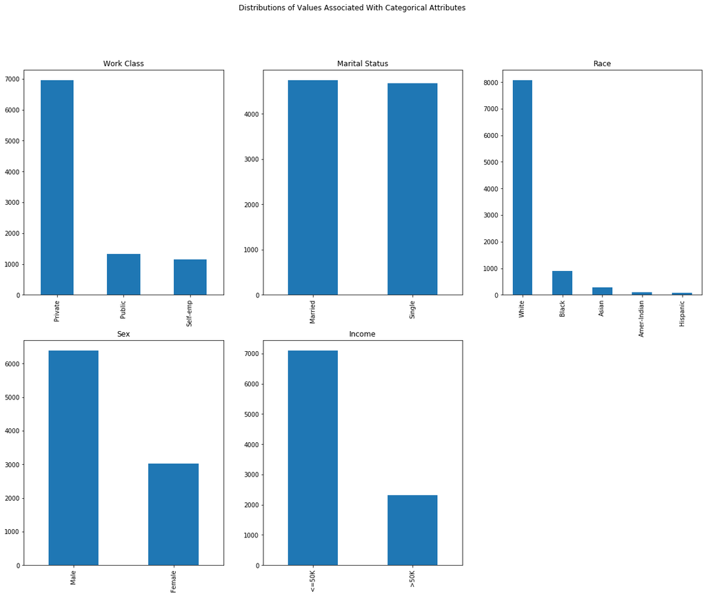

```python
f,axes = plt.subplots(2,3, figsize =(20,15))
f.delaxes(axes[1,2]) #Delet the third chart in lower level
f.suptitle('Distributions of Values Associated With Categorical Attributes')

ax1 = census_na.workclass.value_counts().plot(kind = 'bar',ax = axes[0,0],title = 'Work Class')
ax2 = census_na['marital-status'].value_counts().plot(kind = 'bar',ax = axes[0,1],title = 'Marital Status')
ax3 = census_na.race.value_counts().plot(kind = 'bar',ax = axes[0,2],title = 'Race')
ax4 = census_na.sex.value_counts().plot(kind = 'bar',ax = axes[1,0],title = 'Sex')
ax5 = census_na.income.value_counts().plot(kind = 'bar',ax = axes[1,1],title = 'Income')
```

[output not shown]

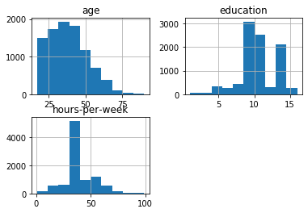

```python
census_na.hist()
```

```python
census_na.groupby("income").describe().T
```

|  | income | <=50K | >50K |
| --- | --- | --- | --- |
| age | count | 7093.000000 | 2319.000000 |
|  | mean | 36.635979 | 43.622251 |
|  | std | 13.339117 | 10.047667 |
|  | min | 17.000000 | 19.000000 |
|  | 25% | 26.000000 | 36.000000 |
|  | 50% | 35.000000 | 43.000000 |
|  | 75% | 45.000000 | 50.000000 |
|  | max | 90.000000 | 90.000000 |
| education | count | 7093.000000 | 2319.000000 |
|  | mean | 9.646976 | 11.588185 |
|  | std | 2.397358 | 2.410764 |
|  | min | 1.000000 | 2.000000 |
|  | 25% | 9.000000 | 9.000000 |
|  | 50% | 9.000000 | 12.000000 |
|  | 75% | 10.000000 | 13.000000 |
|  | max | 16.000000 | 16.000000 |
| hours-per-week | count | 7093.000000 | 2319.000000 |
|  | mean | 39.567038 | 45.708495 |
|  | std | 11.868506 | 10.678794 |
|  | min | 1.000000 | 1.000000 |
|  | 25% | 38.000000 | 40.000000 |
|  | 50% | 40.000000 | 40.000000 |
|  | 75% | 40.000000 | 50.000000 |
|  | max | 99.000000 | 99.000000 |

Perform the following cross-tabulations (including generating bar charts): education+race, work-class+income, work-class+race, and race+income. In the latter case (race+income) also create a table or chart showing percentages of each race category that fall in the low-income group. Discuss your observations from this analysis.

```python
ct1  = pd.crosstab(census_na.education,census_na.race, margins = False)
ct2  = pd.crosstab(census_na.workclass,census_na.income, margins = False)
ct3  = pd.crosstab(census_na.workclass,census_na.race, margins = False)
ct4  = pd.crosstab(census_na.race,census_na.income, margins = False)

print(ct1)
print('\n',ct2)
print('\n',ct3)
print('\n',ct4)
```

```
race       Amer-Indian  Asian  Black  Hispanic  White
education
1                    0      0      1         0     11
2                    0      1      4         3     38
3                    0      4      5         1     71
4                    5      5     14         6    150
5                    0      3     19         2    118
6                    8      3     30         4    223
7                    4      6     49         4    261
8                    0      2     17         3     78
9                   35     67    350        23   2590
10                  26     64    206        11   1818
11                   5     10     33         4    337
12                   4      5     33         3    259
13                   5     75    102         8   1387
14                   0     27     20         1    467
15                   0     11      5         2    153
16                   0      8      4         0    101

 income     <=50K  >50K
workclass
Private     5443  1504
Public       925   392
Self-emp     725   423

 race       Amer-Indian  Asian  Black  Hispanic  White
workclass
Private             65    204    664        64   5950
Public              20     48    192         5   1052
Self-emp             7     39     36         6   1060

 income       <=50K  >50K
race
Amer-Indian     83     9
Asian          224    67
Black          773   119
Hispanic        69     6
White         5944  2118
```

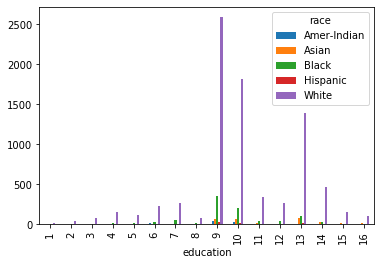

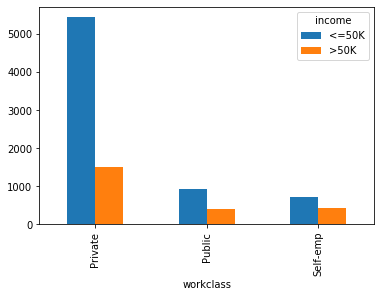

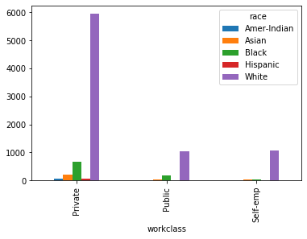

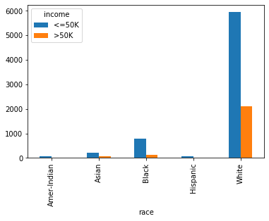

```python
ctax1 = plt.show(ct1.plot(kind = "bar"))
ctax2 = plt.show(ct2.plot(kind = "bar"))
ctax3 = plt.show(ct3.plot(kind = "bar"))
ctax4 = plt.show(ct4.plot(kind = "bar"))
```

In the latter case (race+income) also create a table or chart showing percentages of each race category that fall in the low-income group. Discuss your observations from this analysis.

```python
#ct4  = pd.crosstab(census.race,census.income, margins = False)
ctaxPerc = pd.crosstab(census.race, census.income).apply(lambda r: r/r.sum(), axis=1)
ctaxPerc_Low = ctaxPerc['<=50K']
ctaxPerc_Low
```

```
race
Amer-Indian    0.898990
Asian          0.779935
Black          0.873033
Hispanic       0.927711
White          0.745909
Name: <=50K, dtype: float64
```

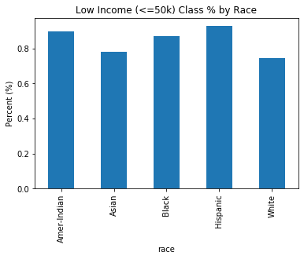

```python
low_incomePLT = ctaxPerc_Low.plot(kind = 'bar', title = 'Low Income (<=50k) Class % by Race')
plt.ylabel('Percent (%)')
low_incomePLT
```

```python
ctaxedu = pd.crosstab(census_na.education ,census_na.income, margins = False).apply(lambda r: r/r.sum(), axis=1)
ctaxedu_Low = ctaxedu['<=50K']
ctaxsex = pd.crosstab(census_na.sex ,census_na.income, margins = False).apply(lambda r: r/r.sum(), axis=1)
ctaxsex_Low = ctaxsex['<=50K']
ctaxmarital= pd.crosstab(census_na['marital-status'] ,census_na.income, margins = False).apply(lambda r: r/r.sum(), axis=1)
ctaxmarital_Low = ctaxmarital['<=50K']
```

Compare and contrast the characteristics of the low-income and high-income categories across the different attributes.

```python
ct5 = pd.crosstab(census_na.education ,census_na.income,margins = False)
ct6 = pd.crosstab(census_na.sex ,census_na.income, margins = False)
ct7 = pd.crosstab(census_na['marital-status'],census_na.income, margins = False)
print(ct2)
print('\n',ct4)
print('\n',ct5)
print('\n',ct6)
print('\n',ct7)
```

```
income     <=50K  >50K
workclass
Private     5443  1504
Public       925   392
Self-emp     725   423

 income       <=50K  >50K
race
Amer-Indian     83     9
Asian          224    67
Black          773   119
Hispanic        69     6
White         5944  2118

 income     <=50K  >50K
education
1             12     0
2             45     1
3             76     5
4            164    16
5            135     7
6            245    23
7            310    14
8             93     7
9           2539   526
10          1737   388
11           298    91
12           221    83
13           921   656
14           225   290
15            45   126
16            27    86

 income  <=50K  >50K
sex
Female   2669   360
Male     4424  1959

 income          <=50K  >50K
marital-status
Married          2730  2007
Single           4363   312
```

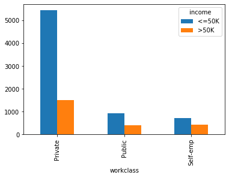

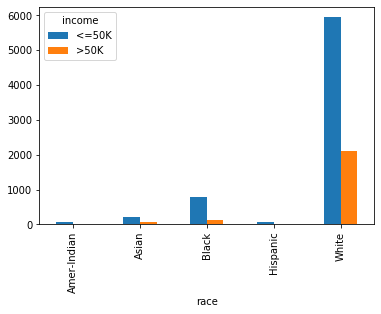

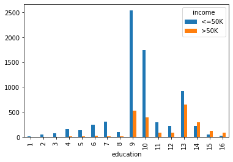

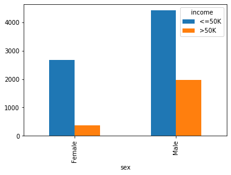

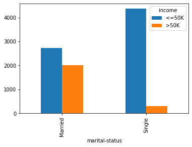

```python
ctax2 = plt.show(ct2.plot(kind = "bar"))
ctax4 = plt.show(ct4.plot(kind = "bar"))
ctax5 = plt.show(ct5.plot(kind = "bar"))
ctax6 = plt.show(ct6.plot(kind = "bar"))
ctax7 = plt.show(ct7.plot(kind = "bar"))
```

In order of the crosstabs we can observe the below:

1. The work class with the highest number of >50k is private. Public and self employed have similar break down of low income and high income.
2. White has the highest amount of high income earners and the highest amount of low income. Black has the next highest amount of low income earners and high income earners. The rest of the races have a similar break down.
3. The majority of low income falls in 9. The majority of high in come is 13.
4. Males have over triple the amount of high income earners than female
5. The amount of married low and high income earners is fairly close, while a majority of singles are low income.

b. Predictive Modeling and Model Evaluation:

Using either Pandas or Scikit-learn, create dummy variables for the categorical attributes. Then separate the target attribute ("income*>50K") from the attributes used for training. [Note: you need to drop "income*<=50K" which is also created as a dummy variable in earlier steps). Split the data into training and test sets (80%-20% split).

```python
census_na.head()
```

|  | age | workclass | education | marital-status | race | sex | hours-per-week | income |
| --- | --- | --- | --- | --- | --- | --- | --- | --- |
| 0 | 39.0 | Public | 13 | Single | White | Male | 40 | <=50K |
| 1 | 50.0 | Self-emp | 13 | Married | White | Male | 13 | <=50K |
| 2 | 38.0 | Private | 9 | Single | White | Male | 40 | <=50K |
| 3 | 53.0 | Private | 7 | Married | Black | Male | 40 | <=50K |
| 4 | 28.0 | Private | 13 | Married | Black | Female | 40 | <=50K |

```python
census_dummies = pd.get_dummies(census_na[['age','workclass','education','marital-status','race','sex','hours-per-week','income']])
census_dummies.head()
```

|  | age | education | hours-per-week | workclass_Private | workclass_Public | workclass_Self-emp | marital-status_Married | marital-status_Single | race_Amer-Indian | race_Asian | race_Black | race_Hispanic | race_White | sex_Female | sex_Male | income_<=50K | income_>50K |
| --- | --- | --- | --- | --- | --- | --- | --- | --- | --- | --- | --- | --- | --- | --- | --- | --- | --- |
| 0 | 39.0 | 13 | 40 | 0 | 1 | 0 | 0 | 1 | 0 | 0 | 0 | 0 | 1 | 0 | 1 | 1 | 0 |
| 1 | 50.0 | 13 | 13 | 0 | 0 | 1 | 1 | 0 | 0 | 0 | 0 | 0 | 1 | 0 | 1 | 1 | 0 |
| 2 | 38.0 | 9 | 40 | 1 | 0 | 0 | 0 | 1 | 0 | 0 | 0 | 0 | 1 | 0 | 1 | 1 | 0 |
| 3 | 53.0 | 7 | 40 | 1 | 0 | 0 | 1 | 0 | 0 | 0 | 1 | 0 | 0 | 0 | 1 | 1 | 0 |
| 4 | 28.0 | 13 | 40 | 1 | 0 | 0 | 1 | 0 | 0 | 0 | 1 | 0 | 0 | 1 | 0 | 1 | 0 |

```python
#drop income_<=50K
census_dummies = census_dummies.drop('income_<=50K',1)
```

```python
census_dummies.head()
```

|  | age | education | hours-per-week | workclass_Private | workclass_Public | workclass_Self-emp | marital-status_Married | marital-status_Single | race_Amer-Indian | race_Asian | race_Black | race_Hispanic | race_White | sex_Female | sex_Male | income_>50K |
| --- | --- | --- | --- | --- | --- | --- | --- | --- | --- | --- | --- | --- | --- | --- | --- | --- |
| 0 | 39.0 | 13 | 40 | 0 | 1 | 0 | 0 | 1 | 0 | 0 | 0 | 0 | 1 | 0 | 1 | 0 |
| 1 | 50.0 | 13 | 13 | 0 | 0 | 1 | 1 | 0 | 0 | 0 | 0 | 0 | 1 | 0 | 1 | 0 |
| 2 | 38.0 | 9 | 40 | 1 | 0 | 0 | 0 | 1 | 0 | 0 | 0 | 0 | 1 | 0 | 1 | 0 |
| 3 | 53.0 | 7 | 40 | 1 | 0 | 0 | 1 | 0 | 0 | 0 | 1 | 0 | 0 | 0 | 1 | 0 |
| 4 | 28.0 | 13 | 40 | 1 | 0 | 0 | 1 | 0 | 0 | 0 | 1 | 0 | 0 | 1 | 0 | 0 |

```python
census_dX = census_dummies.drop('income_>50K',1)
census_dy = census_dummies['income_>50K']
```

```python
census_dX.head()
```

|  | age | education | hours-per-week | workclass_Private | workclass_Public | workclass_Self-emp | marital-status_Married | marital-status_Single | race_Amer-Indian | race_Asian | race_Black | race_Hispanic | race_White | sex_Female | sex_Male |
| --- | --- | --- | --- | --- | --- | --- | --- | --- | --- | --- | --- | --- | --- | --- | --- |
| 0 | 39.0 | 13 | 40 | 0 | 1 | 0 | 0 | 1 | 0 | 0 | 0 | 0 | 1 | 0 | 1 |
| 1 | 50.0 | 13 | 13 | 0 | 0 | 1 | 1 | 0 | 0 | 0 | 0 | 0 | 1 | 0 | 1 |
| 2 | 38.0 | 9 | 40 | 1 | 0 | 0 | 0 | 1 | 0 | 0 | 0 | 0 | 1 | 0 | 1 |
| 3 | 53.0 | 7 | 40 | 1 | 0 | 0 | 1 | 0 | 0 | 0 | 1 | 0 | 0 | 0 | 1 |
| 4 | 28.0 | 13 | 40 | 1 | 0 | 0 | 1 | 0 | 0 | 0 | 1 | 0 | 0 | 1 | 0 |

```python
census_dy.head(10) #0 = below 1 = above
```

```
0    0
1    0
2    0
3    0
4    0
5    0
6    0
7    1
8    1
9    1
Name: income_>50K, dtype: uint8
```

```python
census_dX_train, census_dX_test, census_dy_train, census_dy_test = train_test_split(census_dX, census_dy, test_size= 0.2,random_state = 33)
print(census_dX_train.shape)
print(census_dX_test.shape)
```

```
(7529, 15)
(1883, 15)
```

Use scikit-learn to build classifiers using

1. Naive Bayes (Gaussian),
2. decision tree (using "gini" as selection criteria)
3. linear discriminant analysis (LDA)

For each of these perform 10-fold cross-validation on the training data (using cross-validation module in scikit-learn) and report the overall average accuracy. Compare this to the model accuracy on the training data. Finally, run your model on the set-aside test data.

1. Naive Bayes

```python
from sklearn import naive_bayes,tree
from sklearn.discriminant_analysis import LinearDiscriminantAnalysis
```

```python
nbclf = naive_bayes.GaussianNB()
nbclf = nbclf.fit(census_dX_train,census_dy_train)
nbpreds_train = nbclf.predict(census_dX_train)
nbpreds_test = nbclf.predict(census_dX_test)
print(nbpreds_test)
```

```
[1 1 0 ... 1 0 1]
```

```python
from sklearn.model_selection import cross_val_score
```

Naive Bayes Cross Validation Score

```python
nbcv_scores = cross_val_score(nbclf,census_dX,census_dy,cv = 10)
print("Overall Accuracy: %0.3f (+/- %0.3f)" % (nbcv_scores.mean(), nbcv_scores.std() * 2))
```

```
Overall Accuracy: 0.718 (+/- 0.023)
```

Naive Bayes Training Data Accuracy

```python
print(round(nbclf.score(census_dX_train, census_dy_train),3))
```

```
0.721
```

Naive Bayes Test Data Accuracy

```python
print(round(nbclf.score(census_dX_test, census_dy_test),3))
```

```
0.719
```

```python
print(classification_report(census_dy_test, nbpreds_test))
```

```
              precision    recall  f1-score   support

           0       0.90      0.71      0.80      1443
           1       0.44      0.74      0.55       440

    accuracy                           0.72      1883
   macro avg       0.67      0.73      0.67      1883
weighted avg       0.79      0.72      0.74      1883
```

```python
nbcm = confusion_matrix(census_dy_test,nbpreds_test)
print(nbcm)
```

```
[[1027  416]
 [ 113  327]]
```

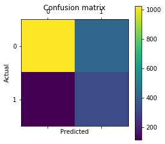

```python
import pylab as plt
%matplotlib inline
plt.matshow(nbcm)
plt.title('Confusion matrix')
plt.colorbar()
plt.ylabel('Actual')
plt.xlabel('Predicted')
plt.show()
```

1. Decision Tree

```python
treeclf = tree.DecisionTreeClassifier(criterion='gini')
```

```python
treeclf = treeclf.fit(census_dX_train,census_dy_train)
treepred_train = treeclf.predict(census_dX_train)
treepred_test = treeclf.predict(census_dX_test)
print(treepred_test)
```

```
[0 1 0 ... 0 0 1]
```

```python
treecv_scores = cross_val_score(treeclf,census_dX,census_dy,cv = 10)
print("Overall Accuracy: %0.3f (+/- %0.3f)" % (treecv_scores.mean(), treecv_scores.std() * 2))
```

```
Overall Accuracy: 0.768 (+/- 0.021)
```

```python
print(round(treeclf.score(census_dX_train, census_dy_train),3))
```

```
0.943
```

```python
print(round(treeclf.score(census_dX_test, census_dy_test),3))
```

```
0.765
```

```python
print(classification_report(census_dy_test, treepred_test))
```

```
              precision    recall  f1-score   support

           0       0.83      0.87      0.85      1443
           1       0.50      0.43      0.46       440

    accuracy                           0.77      1883
   macro avg       0.67      0.65      0.66      1883
weighted avg       0.75      0.77      0.76      1883
```

```python
treecm = confusion_matrix(census_dy_test,treepred_test)
print(treecm)
```

```
[[1252  191]
 [ 251  189]]
```

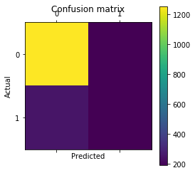

```python
import pylab as plt
%matplotlib inline
plt.matshow(treecm)
plt.title('Confusion matrix')
plt.colorbar()
plt.ylabel('Actual')
plt.xlabel('Predicted')
plt.show()
```

1. Linear Discriminant Analysis

```python
from sklearn.discriminant_analysis import LinearDiscriminantAnalysis
```

```python
ldclf = LinearDiscriminantAnalysis()
```

```python
ldclf = ldclf.fit(census_dX_train,census_dy_train)
ldclfpred_train = ldclf.predict(census_dX_train)
ldclfpred_test = ldclf.predict(census_dX_test)
print(ldclfpred_test)
```

```
[1 0 0 ... 0 0 1]
```

```python
ldcv_scores = cross_val_score(ldclf,census_dX,census_dy,cv = 10)
print("Overall Accuracy: %0.3f (+/- %0.3f)" % (ldcv_scores.mean(), ldcv_scores.std() * 2))
```

```
Overall Accuracy: 0.808 (+/- 0.020)
```

```python
print(round(ldclf.score(census_dX_train, census_dy_train),3))
```

```
0.806
```

```python
print(round(ldclf.score(census_dX_test, census_dy_test),3))
```

```
0.81
```

LDA held the highest test accuracy amongst the 3 in problem 3

```python
print(classification_report(census_dy_test, ldclfpred_test))
```

```
              precision    recall  f1-score   support

           0       0.85      0.91      0.88      1443
           1       0.62      0.49      0.55       440

    accuracy                           0.81      1883
   macro avg       0.74      0.70      0.71      1883
weighted avg       0.80      0.81      0.80      1883
```

```python
ldcm = confusion_matrix(census_dy_test,ldclfpred_test)
print(ldcm)
```

```
[[1310  133]
 [ 224  216]]
```

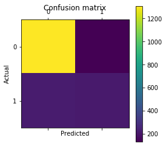

```python
import pylab as plt
%matplotlib inline
plt.matshow(ldcm)
plt.title('Confusion matrix')
plt.colorbar()
plt.ylabel('Actual')
plt.xlabel('Predicted')
plt.show()
```